# Bayesian data analysis - BRMS demos

```r
fit_bern <- brm(y ~ 1, family = bernoulli(), data = data_bern,
                prior = prior(student_t(7, 0, 1.5), class='Intercept'),
                seed = SEED, refresh = 0)
```

Check the summary of the posterior and convergence

```r
fit_bern
```

```
 Family: bernoulli
  Links: mu = logit
Formula: y ~ 1
   Data: data_bern (Number of observations: 10)
  Draws: 4 chains, each with iter = 2000; warmup = 1000; thin = 1;
         total post-warmup draws = 4000

Population-Level Effects:
          Estimate Est.Error l-95% CI u-95% CI Rhat Bulk_ESS Tail_ESS
Intercept     0.76      0.64    -0.43     2.09 1.00     1734     1726

Draws were sampled using sample(hmc). For each parameter, Bulk_ESS
and Tail_ESS are effective sample size measures, and Rhat is the potential
scale reduction factor on split chains (at convergence, Rhat = 1).
```

Extract the posterior draws

```r
draws <- as_draws_df(fit_bern)
```

We can get summary information using summarise_draws()

```r
draws |>
  subset_draws(variable='b_Intercept') |>
  summarise_draws()
```

```
# A tibble: 1 × 10
  variable     mean median    sd   mad     q5   q95  rhat ess_bulk ess_tail
  <chr>       <dbl>  <dbl> <dbl> <dbl>  <dbl> <dbl> <dbl>    <dbl>    <dbl>
1 b_Intercept 0.763  0.746 0.641 0.636 -0.242  1.90  1.00    1734.    1726.
```

We can compute the probability of success by using plogis which is equal to inverse-logit function

```r
draws <- draws |>
  mutate_variables(theta=plogis(b_Intercept))
```

Summary of theta by using summarise_draws()

```r
draws |>
  subset_draws(variable='theta') |>
  summarise_draws()
```

```
# A tibble: 1 × 10
  variable  mean median    sd   mad    q5   q95  rhat ess_bulk ess_tail
  <chr>    <dbl>  <dbl> <dbl> <dbl> <dbl> <dbl> <dbl>    <dbl>    <dbl>
1 theta    0.668  0.678 0.130 0.134 0.440 0.870  1.00    1734.    1726.
```

Histogram of theta

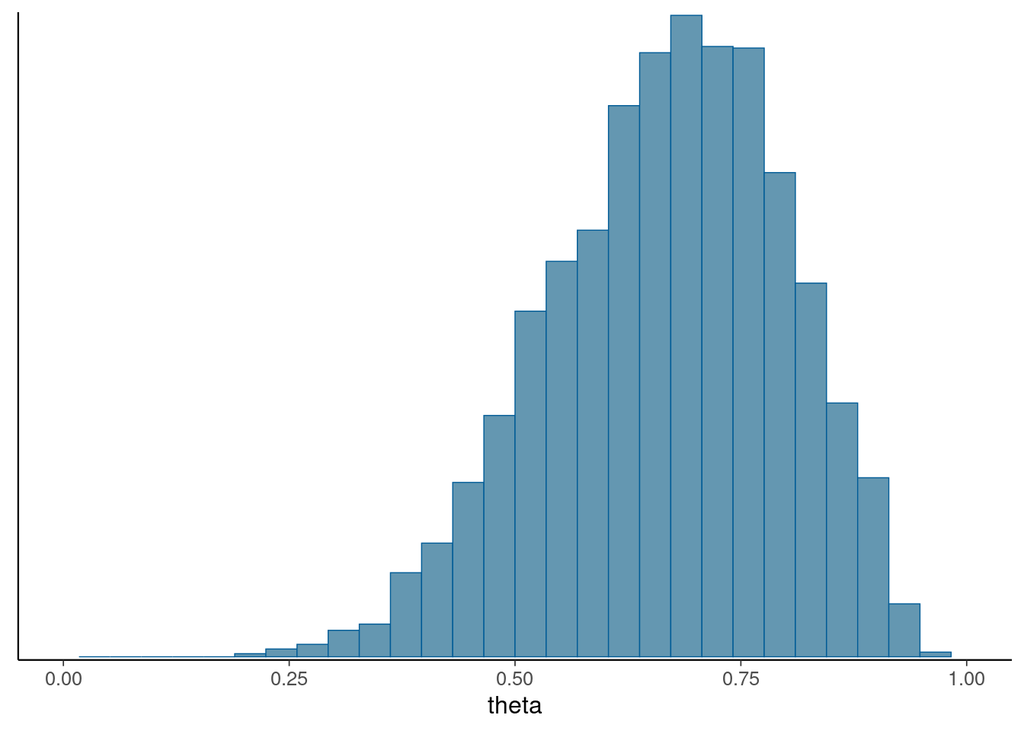

```r
mcmc_hist(draws, pars='theta') +
  xlab('theta') +
  xlim(c(0,1))
```

Make prior sensitivity analysis by powerscaling both prior and likelihood. Focus on theta which is the quantity of interest.

```r
theta <- draws |>
  subset_draws(variable='theta')
powerscale_sensitivity(fit_bern, prediction = \(x, ...) theta, num_args=list(digits=2)
                       )$sensitivity |>
                         filter(variable=='theta') |>
                         mutate(across(where(is.double),  ~num(.x, digits=2)))
```

```
# A tibble: 1 × 4
  variable     prior likelihood diagnosis
  <chr>    <num:.2!>  <num:.2!> <chr>
1 theta         0.04       0.11 -
```

# 3 Binomial model

Instead of sequence of 0’s and 1’s, we can summarize the data with the number of trials and the number successes and use Binomial model. The prior is specified in the ‘latent space’. The actual probability of success, theta = plogis(alpha), where plogis is the inverse of the logistic function.

Binomial model with the same data and prior

```r
data_bin <- data.frame(N = c(10), y = c(7))
```

Formula `y | trials(N) ~ 1` corresponds to a model $\mathrm{logit}(\theta) = \alpha$, and the number of trials for each observation is provided by `| trials(N)`

```r
fit_bin <- brm(y | trials(N) ~ 1, family = binomial(), data = data_bin,
               prior = prior(student_t(7, 0,1.5), class='Intercept'),
               seed = SEED, refresh = 0)
```

Check the summary of the posterior and convergence

```r
fit_bin
```

```
 Family: binomial
  Links: mu = logit
Formula: y | trials(N) ~ 1
   Data: data_bin (Number of observations: 1)
  Draws: 4 chains, each with iter = 2000; warmup = 1000; thin = 1;
         total post-warmup draws = 4000

Population-Level Effects:
          Estimate Est.Error l-95% CI u-95% CI Rhat Bulk_ESS Tail_ESS
Intercept     0.77      0.64    -0.46     2.09 1.00     1660     1769

Draws were sampled using sample(hmc). For each parameter, Bulk_ESS
and Tail_ESS are effective sample size measures, and Rhat is the potential
scale reduction factor on split chains (at convergence, Rhat = 1).
```

Extract the posterior draws

```r
draws <- as_draws_df(fit_bin)
```

We can get summary information using summarise_draws()

```r
draws |>
  subset_draws(variable='b_Intercept') |>
  summarise_draws()
```

```
# A tibble: 1 × 10
  variable     mean median    sd   mad     q5   q95  rhat ess_bulk ess_tail
  <chr>       <dbl>  <dbl> <dbl> <dbl>  <dbl> <dbl> <dbl>    <dbl>    <dbl>
1 b_Intercept 0.767  0.758 0.636 0.622 -0.249  1.88  1.00    1660.    1769.
```

We can compute the probability of success by using plogis which is equal to inverse-logit function

```r
draws <- draws |>
  mutate_variables(theta=plogis(b_Intercept))
```

Summary of theta by using summarise_draws()

```r
draws |>
  subset_draws(variable='theta') |>
  summarise_draws()
```

```
# A tibble: 1 × 10
  variable  mean median    sd   mad    q5   q95  rhat ess_bulk ess_tail
  <chr>    <dbl>  <dbl> <dbl> <dbl> <dbl> <dbl> <dbl>    <dbl>    <dbl>
1 theta    0.669  0.681 0.130 0.132 0.438 0.868  1.00    1660.    1769.
```

Histogram of theta

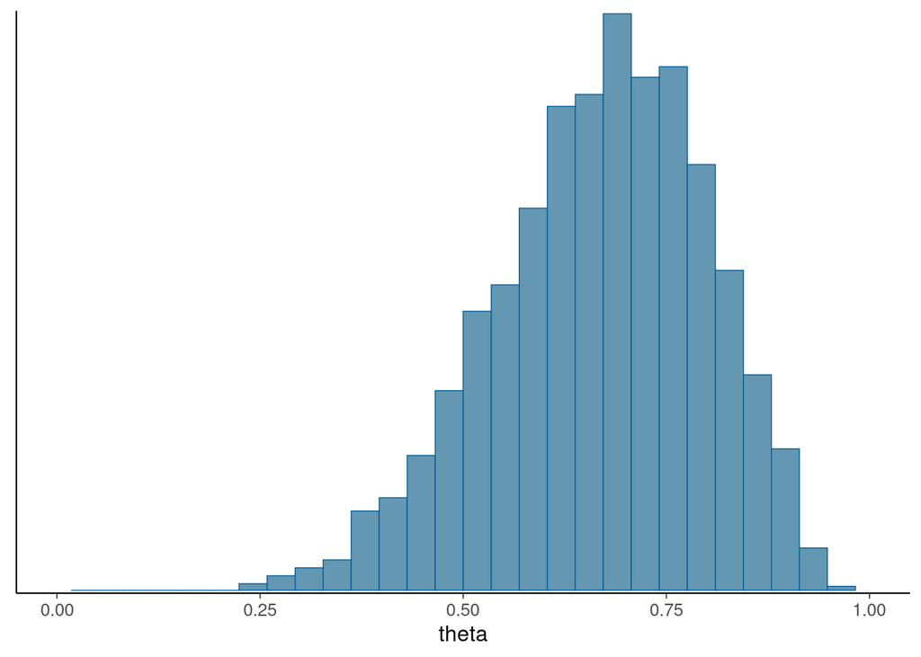

```r
mcmc_hist(draws, pars='theta') +
  xlab('theta') +
  xlim(c(0,1))
```

Re-run the model with a new data dataset without recompiling

```r
data_bin <- data.frame(N = c(5), y = c(4))
fit_bin <- update(fit_bin, newdata = data_bin)
```

Check the summary of the posterior and convergence

```r
fit_bin
```

```
 Family: binomial
  Links: mu = logit
Formula: y | trials(N) ~ 1
   Data: data_bin (Number of observations: 1)
  Draws: 4 chains, each with iter = 2000; warmup = 1000; thin = 1;
         total post-warmup draws = 4000

Population-Level Effects:
          Estimate Est.Error l-95% CI u-95% CI Rhat Bulk_ESS Tail_ESS
Intercept     1.05      0.91    -0.59     3.06 1.00     1422     1684

Draws were sampled using sample(hmc). For each parameter, Bulk_ESS
and Tail_ESS are effective sample size measures, and Rhat is the potential
scale reduction factor on split chains (at convergence, Rhat = 1).
```

Extract the posterior draws

```r
draws <- as_draws_df(fit_bin)
```

We can get summary information using summarise_draws()

```r
draws |>
  subset_draws(variable='b_Intercept') |>
  summarise_draws()
```

```
# A tibble: 1 × 10
  variable     mean median    sd   mad     q5   q95  rhat ess_bulk ess_tail
  <chr>       <dbl>  <dbl> <dbl> <dbl>  <dbl> <dbl> <dbl>    <dbl>    <dbl>
1 b_Intercept  1.05  0.998 0.911 0.866 -0.370  2.63  1.00    1422.    1684.
```

We can compute the probability of success by using plogis which is equal to inverse-logit function

```r
draws <- draws |>
  mutate_variables(theta=plogis(b_Intercept))
```

Summary of theta by using summarise_draws()

```r
draws |>
  subset_draws(variable='theta') |>
  summarise_draws()
```

```
# A tibble: 1 × 10
  variable  mean median    sd   mad    q5   q95  rhat ess_bulk ess_tail
  <chr>    <dbl>  <dbl> <dbl> <dbl> <dbl> <dbl> <dbl>    <dbl>    <dbl>
1 theta    0.709  0.731 0.160 0.164 0.409 0.932  1.00    1422.    1684.
```

Histogram of theta

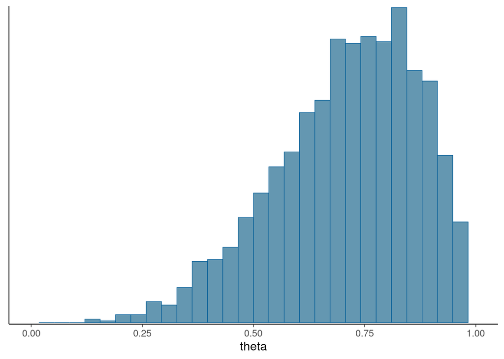

```r
mcmc_hist(draws, pars='theta') +
  xlab('theta') +
  xlim(c(0,1))
```

# 4 Comparison of two groups with Binomial

An experiment was performed to estimate the effect of beta-blockers on mortality of cardiac patients. A group of patients were randomly assigned to treatment and control groups:

- out of 674 patients receiving the control, 39 died
- out of 680 receiving the treatment, 22 died

Data, where `grp2` is an indicator variable defined as a factor type, which is useful for categorical variables.

```r
data_bin2 <- data.frame(N = c(674, 680), y = c(39,22), grp2 = factor(c('control','treatment')))
```

To analyse whether the treatment is useful, we can use Binomial model for both groups and compute odds-ratio. To recreate the model as two independent (separate) binomial models, we use formula `y | trials(N) ~ 0 + grp2`, which corresponds to a model $\mathrm{logit}(\theta) = \alpha \times 0 + \beta_\mathrm{control}\times x_\mathrm{control} + \beta_\mathrm{treatment}\times x_\mathrm{treatment} = \beta_\mathrm{control}\times x_\mathrm{control} + \beta_\mathrm{treatment}\times x_\mathrm{treatment}$, where $x_\mathrm{control}$ is a vector with 1 for control and 0 for treatment, and $x_\mathrm{treatemnt}$ is a vector with 1 for treatemnt and 0 for control. As only of the vectors have 1, this corresponds to separate models $\mathrm{logit}(\theta_\mathrm{control}) = \beta_\mathrm{control}$ and $\mathrm{logit}(\theta_\mathrm{treatment}) = \beta_\mathrm{treatment}$. We can provide the same prior for all $\beta$’s by setting the prior with `class='b'`. With prior `student_t(7, 0,1.5)`, both $\beta$’s are shrunk towards 0, but independently.

```r
fit_bin2 <- brm(y | trials(N) ~ 0 + grp2, family = binomial(), data = data_bin2,
                prior = prior(student_t(7, 0,1.5), class='b'),
                seed = SEED, refresh = 0)
```

```r
fit_bin2
```

```
 Family: binomial
  Links: mu = logit
Formula: y | trials(N) ~ 0 + grp2
   Data: data_bin2 (Number of observations: 2)
  Draws: 4 chains, each with iter = 2000; warmup = 1000; thin = 1;
         total post-warmup draws = 4000

Population-Level Effects:
              Estimate Est.Error l-95% CI u-95% CI Rhat Bulk_ESS Tail_ESS
grp2control      -2.77      0.16    -3.10    -2.48 1.00     3563     3085
grp2treatment    -3.37      0.22    -3.81    -2.93 1.00     3824     1939

Draws were sampled using sample(hmc). For each parameter, Bulk_ESS
and Tail_ESS are effective sample size measures, and Rhat is the potential
scale reduction factor on split chains (at convergence, Rhat = 1).
```

Compute theta for each group and the odds-ratio. `brms` uses bariable names `b_grp2control` and `b_grp2treatment` for $\beta_\mathrm{control}$ and $\beta_\mathrm{treatment}$ respectively.

```r
draws_bin2 <- as_draws_df(fit_bin2) |>
  mutate(theta_control = plogis(b_grp2control),
         theta_treatment = plogis(b_grp2treatment),
         oddsratio = (theta_treatment/(1-theta_treatment))/(theta_control/(1-theta_control)))
```

Plot oddsratio

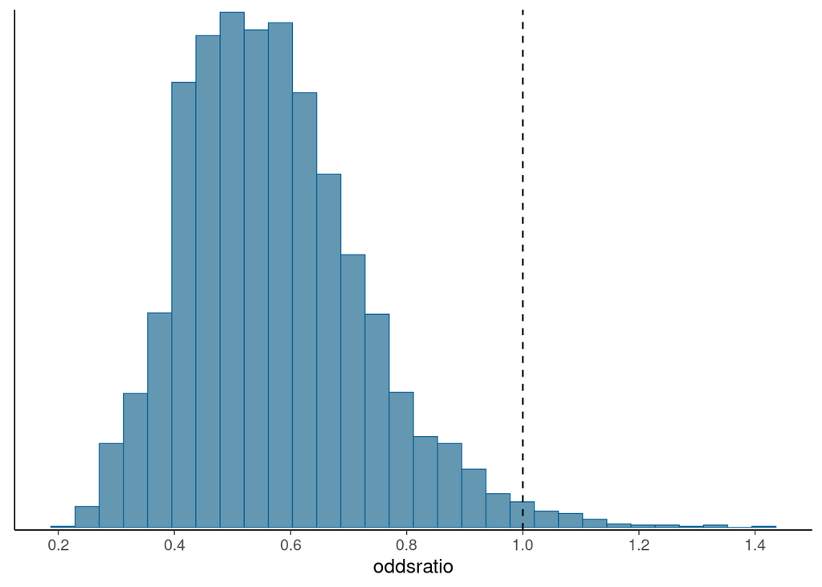

```r
mcmc_hist(draws_bin2, pars='oddsratio') +
  scale_x_continuous(breaks=seq(0.2,1.6,by=0.2))+
  geom_vline(xintercept=1, linetype='dashed')
```

Probability that the oddsratio<1

```r
draws_bin2 |>
  mutate(poddsratio = oddsratio<1) |>
  subset(variable='poddsratio') |>
  summarise_draws(mean, mcse_mean)
```

```
# A tibble: 1 × 3
  variable    mean mcse_mean
  <chr>      <dbl>     <dbl>
1 poddsratio 0.986   0.00230
```

oddsratio 95% posterior interval

```r
draws_bin2 |>
  subset(variable='oddsratio') |>
  summarise_draws(~quantile(.x, probs = c(0.025, 0.975)), ~mcse_quantile(.x, probs = c(0.025, 0.975)))
```

```
# A tibble: 1 × 5
  variable  `2.5%` `97.5%` mcse_q2.5 mcse_q97.5
  <chr>      <dbl>   <dbl>     <dbl>      <dbl>
1 oddsratio  0.317   0.931   0.00586     0.0134
```

Make prior sensitivity analysis by powerscaling both prior and likelihood. Focus on oddsratio which is the quantity of interest. We see that the likelihood is much more informative than the prior, and we would expect to see a different posterior only with a highly informative prior (possibly based on previous similar experiments).

```r
oddsratio <- draws_bin2 |>
  subset_draws(variable='oddsratio')
powerscale_sensitivity(fit_bin2, prediction = \(x, ...) oddsratio, num_args=list(digits=2)
                       )$sensitivity |>
                         filter(variable=='oddsratio') |>
                         mutate(across(where(is.double),  ~num(.x, digits=2)))
```

```
# A tibble: 1 × 4
  variable      prior likelihood diagnosis
  <chr>     <num:.2!>  <num:.2!> <chr>
1 oddsratio      0.01       0.14 -
```

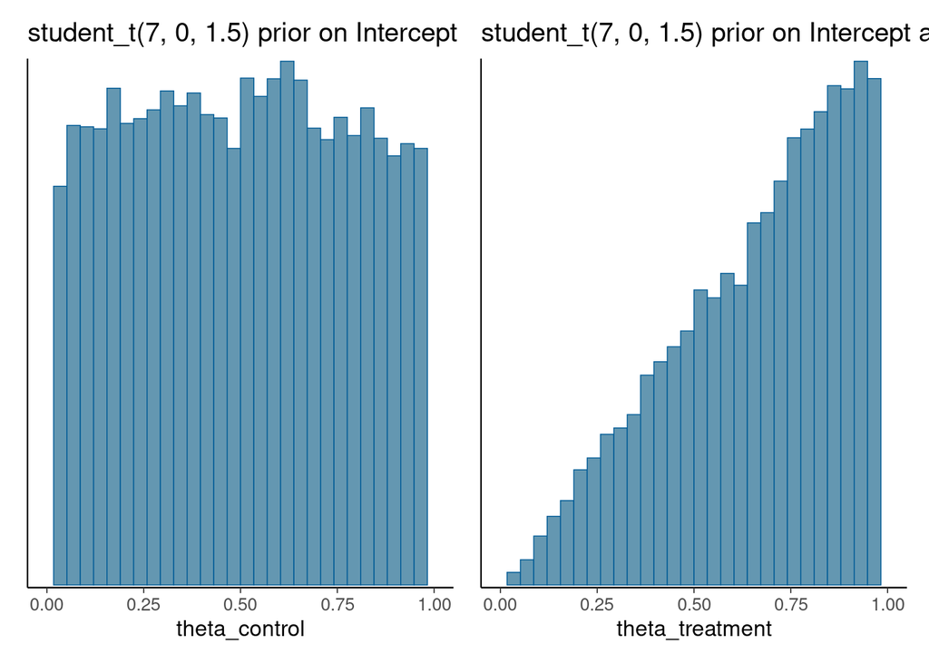

```r
data.frame(theta_control = plogis(ggdist::rstudent_t(n=20000, df=7, mu=0, sigma=1.5))) |>
  mcmc_hist() +
  xlim(c(0,1)) +
  labs(title='student_t(7, 0, 1.5) prior on Intercept') +
data.frame(theta_treatment = plogis(ggdist::rstudent_t(n=20000, df=7, mu=0, sigma=1.5))+
             plogis(ggdist::rstudent_t(n=20000, df=7, mu=0, sigma=1.5))) |>
  mcmc_hist() +
  xlim(c(0,1)) +
  labs(title='student_t(7, 0, 1.5) prior on Intercept and b_grp2treatment')
```

In this case, with relatively big treatment and control group, the likelihood is informative, and the difference between using `y | trials(N) ~ 0 + grp2` or `y | trials(N) ~ grp2` is negligible.

Third option would be a hierarchical model with formula `y | trials(N) ~ 1 + (1 | grp2)`, which is equivalent to `y | trials(N) ~ 1 + (1 | grp2)`, and corresponds to a model $\mathrm{logit}(\theta) = \alpha \times 1 + \beta_\mathrm{control}\times x_\mathrm{control} + \beta_\mathrm{treatment}\times x_\mathrm{treatment}$, but now the prior on $\beta_\mathrm{control}$ and $\beta_\mathrm{treatment}$ is $\mathrm{normal}(0, \sigma_\mathrm{grp})$. The default `brms` prior for $\sigma_\mathrm{grp}$ is `student_t(3, 0, 2.5)`. Now $\alpha$ models the overall probablity of death (via logistic link), and $\beta_\mathrm{control}$ and $\beta_\mathrm{treatment}$ model the difference from that having the same prior. Prior for $\beta_\mathrm{control}$ and $\beta_\mathrm{treatment}$ includes unknown scale $\sigma_\mathrm{grp}$. If the there is not difference between control and treatment groups, the posterior of $\sigma_\mathrm{grp}$ has more mass near 0, and bigger the difference between control and treatment groups are, more mass there is away from 0. With just two groups, there is not much information about $\sigma_\mathrm{grp}$, and unless there is a informative prior on $\sigma_\mathrm{grp}$, two group hierarchical model is not that useful. Hierarchical models are more useful with more than two groups. In the following, we use the previously used `student_t(7, 0,1.5)` prior on intercept and the default `brms` prior `student_t(3, 0, 2.5)` on $\sigma_\mathrm{grp}$.

```r
fit_bin2 <- brm(y | trials(N) ~ 1 + (1 | grp2), family = binomial(), data = data_bin2,
                prior = prior(student_t(7, 0,1.5), class='Intercept'),
                seed = SEED, refresh = 0, control=list(adapt_delta=0.99))
```

Check the summary of the posterior and convergence. The summary reports that there are Group-Level Effects: `~grp2` with 2 levels (control and treatment), with `sd(Intercept)` denoting $\sigma_\mathrm{grp}$. In addition, the summary lists Population-Level Effects: `Intercept` ($\alpha$) as in the prevous non-hierarchical models.

```r
fit_bin2
```

```
 Family: binomial
  Links: mu = logit
Formula: y | trials(N) ~ 1 + (1 | grp2)
   Data: data_bin2 (Number of observations: 2)
  Draws: 4 chains, each with iter = 2000; warmup = 1000; thin = 1;
         total post-warmup draws = 4000

Group-Level Effects:
~grp2 (Number of levels: 2)
              Estimate Est.Error l-95% CI u-95% CI Rhat Bulk_ESS Tail_ESS
sd(Intercept)     1.69      1.57     0.15     5.69 1.01      538     1113

Population-Level Effects:
          Estimate Est.Error l-95% CI u-95% CI Rhat Bulk_ESS Tail_ESS
Intercept    -2.18      1.28    -3.85     1.01 1.01      569     1027

Draws were sampled using sample(hmc). For each parameter, Bulk_ESS
and Tail_ESS are effective sample size measures, and Rhat is the potential
scale reduction factor on split chains (at convergence, Rhat = 1).
```

We can also look at the variable names `brms` uses internally

```r
as_draws_rvars(fit_bin2)
```

```
# A draws_rvars: 1000 iterations, 4 chains, and 5 variables
$b_Intercept: rvar<1000,4>[1] mean ± sd:
[1] -2.2 ± 1.3

$sd_grp2__Intercept: rvar<1000,4>[1] mean ± sd:
[1] 1.7 ± 1.6

$r_grp2: rvar<1000,4>[2,1] mean ± sd:
          Intercept
control   -0.63 ± 1.3
treatment -1.19 ± 1.3

$lprior: rvar<1000,4>[1] mean ± sd:
[1] -4.3 ± 0.74

$lp__: rvar<1000,4>[1] mean ± sd:
[1] -13 ± 1.8
```

Although there is no difference, illustrate how to compute the oddsratio from hierarchical model

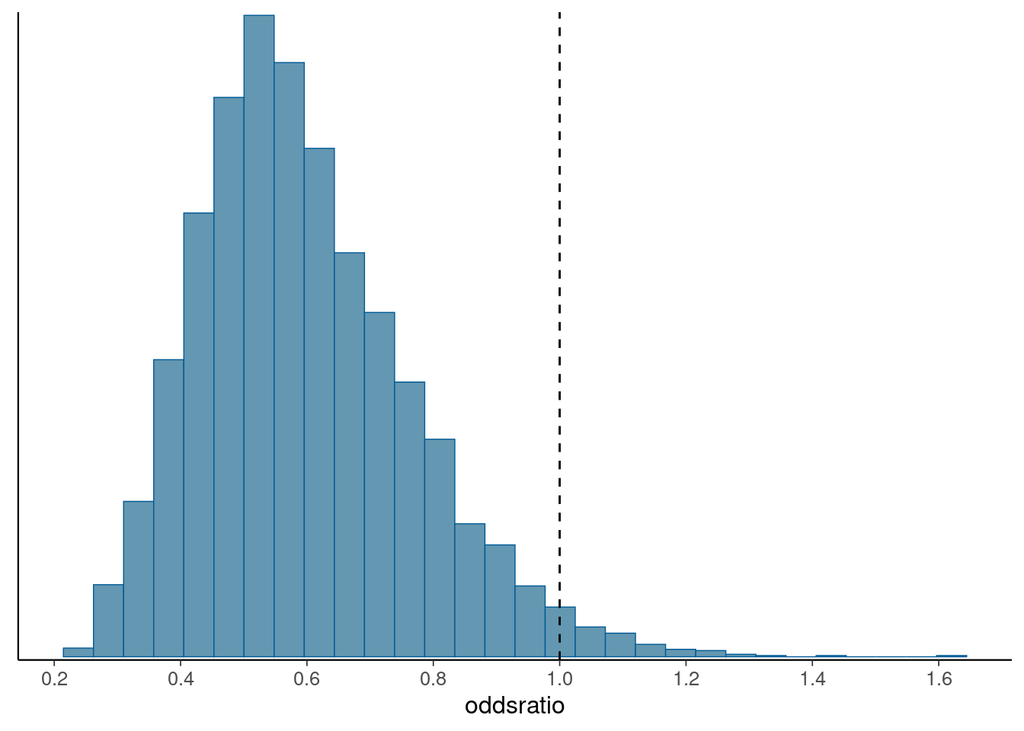

```r
draws_bin2 <- as_draws_df(fit_bin2)
oddsratio <- draws_bin2 |>
  mutate_variables(theta_control = plogis(b_Intercept + `r_grp2[control,Intercept]`),
                   theta_treatment = plogis(b_Intercept + `r_grp2[treatment,Intercept]`),
                   oddsratio = (theta_treatment/(1-theta_treatment))/(theta_control/(1-theta_control))) |>
  subset_draws(variable='oddsratio')
oddsratio |> mcmc_hist() +
  scale_x_continuous(breaks=seq(0.2,1.6,by=0.2))+
  geom_vline(xintercept=1, linetype='dashed')
```

Make also prior sensitivity analysis with focus on oddsratio.

```r
powerscale_sensitivity(fit_bin2, prediction = \(x, ...) oddsratio, num_args=list(digits=2)
                       )$sensitivity |>
                         filter(variable=='oddsratio') |>
                         mutate(across(where(is.double),  ~num(.x, digits=2)))
```

```
# A tibble: 1 × 4
  variable      prior likelihood diagnosis
  <chr>     <num:.2!>  <num:.2!> <chr>
1 oddsratio      0.00       0.16 -
```

# 5 Linear Gaussian model

Use the Kilpisjärvi summer month temperatures 1952–2022 data from `aaltobda` package

```r
load(url('https://github.com/avehtari/BDA_course_Aalto/raw/master/rpackage/data/kilpisjarvi2022.rda'))
data_lin <- data.frame(year = kilpisjarvi2022$year,
                       temp = kilpisjarvi2022$temp.summer)
```

Plot the data

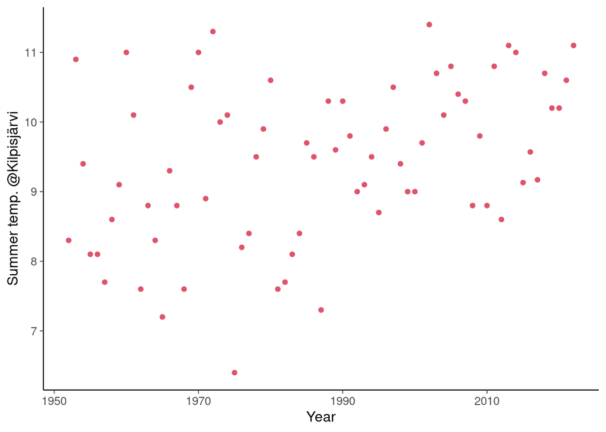

```r
data_lin |>
  ggplot(aes(year, temp)) +
  geom_point(color=2) +
  labs(x= "Year", y = 'Summer temp. @Kilpisjärvi') +
  guides(linetype = "none")
```

To analyse has there been change in the average summer month temperature we use a linear model with Gaussian model for the unexplained variation. By default brms uses uniform prior for the coefficients.

```r
fit_lin <- brm(temp ~ year, data = data_lin, family = gaussian(),
               seed = SEED, refresh = 0)
```

Check the summary of the posterior and convergence.

```r
fit_lin
```

```
 Family: gaussian
  Links: mu = identity; sigma = identity
Formula: temp ~ year
   Data: data_lin (Number of observations: 71)
  Draws: 4 chains, each with iter = 2000; warmup = 1000; thin = 1;
         total post-warmup draws = 4000

Population-Level Effects:
          Estimate Est.Error l-95% CI u-95% CI Rhat Bulk_ESS Tail_ESS
Intercept   -34.69     12.49   -58.73   -10.19 1.00     3995     3035
year          0.02      0.01     0.01     0.03 1.00     3996     3035

Family Specific Parameters:
      Estimate Est.Error l-95% CI u-95% CI Rhat Bulk_ESS Tail_ESS
sigma     1.08      0.09     0.91     1.28 1.00     3057     3011

Draws were sampled using sample(hmc). For each parameter, Bulk_ESS
and Tail_ESS are effective sample size measures, and Rhat is the potential
scale reduction factor on split chains (at convergence, Rhat = 1).
```

Convergence diagnostics look good. We see that posterior mean of `Intercept` is -34.7, which may sound strange, but that is the intercept at year 0, that is, very far from the data range, and thus doesn’t have meaningful interpretation directly. The posterior mean of `year` coefficient is 0.02, that is, we estimate that the summer temperature is increasing 0.02°C per year (which would make 1°C in 50 years).

We can check $R^2$ which corresponds to the proporion of variance explained by the model. The linear model explains 0.16=16% of the total data variance.

```r
bayes_R2(fit_lin) |> round(2)
```

```
   Estimate Est.Error Q2.5 Q97.5
R2     0.16      0.07 0.03   0.3
```

We can check the all the priors used.

```r
prior_summary(fit_lin)
```

```
                  prior     class coef group resp dpar nlpar lb ub       source
                 (flat)         b                                       default
                 (flat)         b year                             (vectorized)
 student_t(3, 9.5, 2.5) Intercept                                       default
   student_t(3, 0, 2.5)     sigma                             0         default
```

```r
fit_lin <- brm(temp ~ year, data = data_lin, family = gaussian(),
               prior = prior(student_t(3, 0, 0.03), class='b'),
               seed = SEED, refresh = 0)
```

Check the summary of the posterior and convergence

```r
fit_lin
```

```
 Family: gaussian
  Links: mu = identity; sigma = identity
Formula: temp ~ year
   Data: data_lin (Number of observations: 71)
  Draws: 4 chains, each with iter = 2000; warmup = 1000; thin = 1;
         total post-warmup draws = 4000

Population-Level Effects:
          Estimate Est.Error l-95% CI u-95% CI Rhat Bulk_ESS Tail_ESS
Intercept   -32.54     12.28   -56.70    -9.01 1.00     4183     3259
year          0.02      0.01     0.01     0.03 1.00     4182     3259

Family Specific Parameters:
      Estimate Est.Error l-95% CI u-95% CI Rhat Bulk_ESS Tail_ESS
sigma     1.08      0.09     0.92     1.27 1.00     3494     2709

Draws were sampled using sample(hmc). For each parameter, Bulk_ESS
and Tail_ESS are effective sample size measures, and Rhat is the potential
scale reduction factor on split chains (at convergence, Rhat = 1).
```

Make prior sensitivity analysis by powerscaling both prior and likelihood.

```r
powerscale_sensitivity(fit_lin)$sensitivity |>
                                mutate(across(where(is.double),  ~num(.x, digits=2)))
```

```
# A tibble: 3 × 4
  variable        prior likelihood diagnosis
  <chr>       <num:.2!>  <num:.2!> <chr>
1 b_Intercept      0.03       0.09 -
2 b_year           0.03       0.09 -
3 sigma            0.00       0.13 -
```

Our weakly informative proper prior has negligible sensitivity, and the likelihood is informative. Extract the posterior draws and check the summaries

```r
draws_lin <- as_draws_df(fit_lin)
draws_lin |> summarise_draws()
```

```
# A tibble: 5 × 10
  variable        mean   median      sd     mad       q5      q95  rhat ess_bulk
  <chr>          <dbl>    <dbl>   <dbl>   <dbl>    <dbl>    <dbl> <dbl>    <dbl>
1 b_Intercept -3.25e+1 -3.24e+1 1.23e+1 1.24e+1 -5.29e+1 -1.29e+1  1.00    4183.
2 b_year       2.11e-2  2.11e-2 6.18e-3 6.22e-3  1.12e-2  3.14e-2  1.00    4182.
3 sigma        1.08e+0  1.07e+0 9.14e-2 9.08e-2  9.43e-1  1.24e+0  1.00    3494.
4 lprior      -1.08e+0 -1.06e+0 1.65e-1 1.65e-1 -1.38e+0 -8.51e-1  1.00    4173.
5 lp__        -1.07e+2 -1.06e+2 1.21e+0 9.72e-1 -1.09e+2 -1.05e+2  1.00    1899.
# ℹ 1 more variable: ess_tail <dbl>
```

If one of the columns is hidden we can force printing all columns

```r
draws_lin |> summarise_draws() |> print(width=Inf)
```

```
# A tibble: 5 × 10
  variable         mean    median       sd      mad        q5       q95  rhat
  <chr>           <dbl>     <dbl>    <dbl>    <dbl>     <dbl>     <dbl> <dbl>
1 b_Intercept  -32.5     -32.4    12.3     12.4      -52.9     -12.9     1.00
2 b_year         0.0211    0.0211  0.00618  0.00622    0.0112    0.0314  1.00
3 sigma          1.08      1.07    0.0914   0.0908     0.943     1.24    1.00
4 lprior        -1.08     -1.06    0.165    0.165     -1.38     -0.851   1.00
5 lp__        -107.     -106.      1.21     0.972   -109.     -105.      1.00
  ess_bulk ess_tail
     <dbl>    <dbl>
1    4183.    3259.
2    4182.    3259.
3    3494.    2709.
4    4173.    3285.
5    1899.    2576.
```

Histogram of b_year

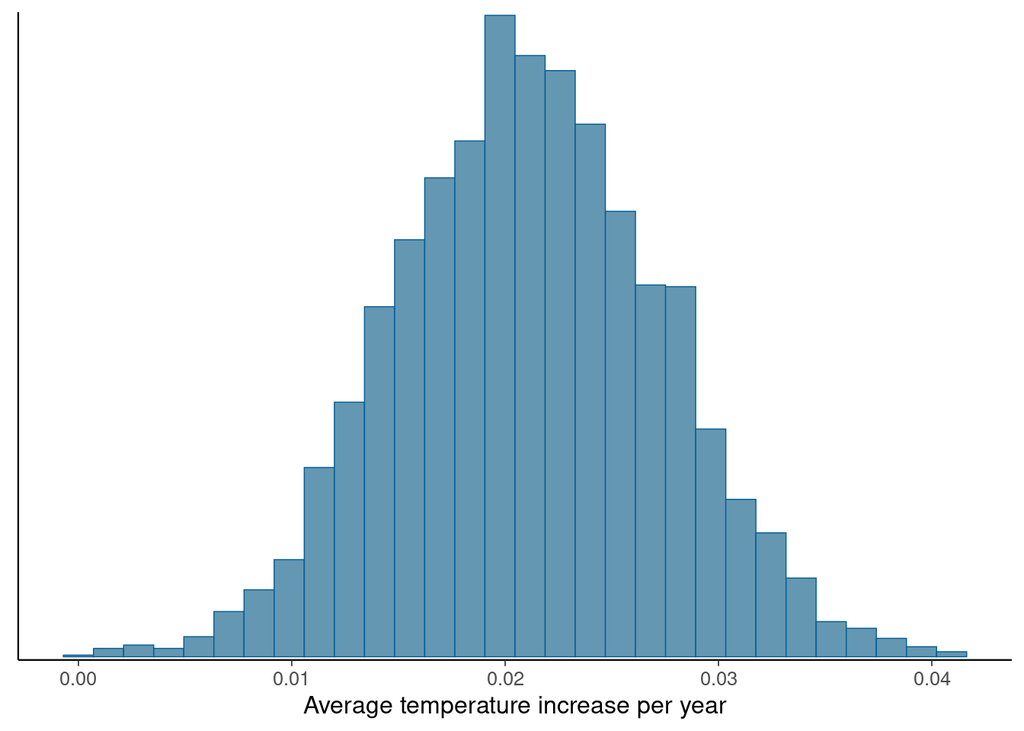

```r
draws_lin |>
  mcmc_hist(pars='b_year') +
  xlab('Average temperature increase per year')
```

Probability that the coefficient b_year > 0 and the corresponding MCSE

```r
draws_lin |>
  mutate(I_b_year_gt_0 = b_year>0) |>
  subset_draws(variable='I_b_year_gt_0') |>
  summarise_draws(mean, mcse_mean)
```

```
# A tibble: 1 × 3
  variable       mean mcse_mean
  <chr>         <dbl>     <dbl>
1 I_b_year_gt_0     1        NA
```

All posterior draws have `b_year>0`, the probability gets rounded to 1, and MCSE is not available as the obserevd posterior variance is 0.

95% posterior interval for temperature increase per 100 years

```r
draws_lin |>
  mutate(b_year_100 = b_year*100) |>
  subset_draws(variable='b_year_100') |>
  summarise_draws(~quantile(.x, probs = c(0.025, 0.975)),
                  ~mcse_quantile(.x, probs = c(0.025, 0.975)),
                  .num_args = list(digits = 2, notation = "dec"))
```

```
# A tibble: 1 × 5
  variable   `2.5%` `97.5%` mcse_q2.5 mcse_q97.5
  <chr>       <dbl>   <dbl>     <dbl>      <dbl>
1 b_year_100   0.93    3.33      0.03       0.03
```

Plot posterior draws of the linear function values at each year. `add_linpred_draws()` takes the years from the data and uses `fit_lin` to make the predictions.

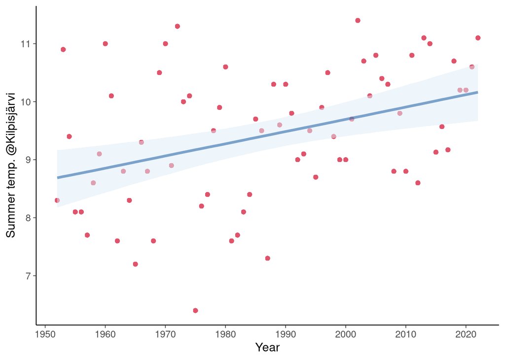

```r
data_lin |>
  add_linpred_draws(fit_lin) |>
  # plot data
  ggplot(aes(x=year, y=temp)) +
  geom_point(color=2) +
  # plot lineribbon for the linear model
  stat_lineribbon(aes(y = .linpred), .width = c(.95), alpha = 1/2, color=brewer.pal(5, "Blues")[[5]]) +
  # decoration
  scale_fill_brewer()+
  labs(x= "Year", y = 'Summer temp. @Kilpisjärvi') +
  theme(legend.position="none")+
  scale_x_continuous(breaks=seq(1950,2020,by=10))
```

Alternativelly plot a spaghetti plot for 100 draws

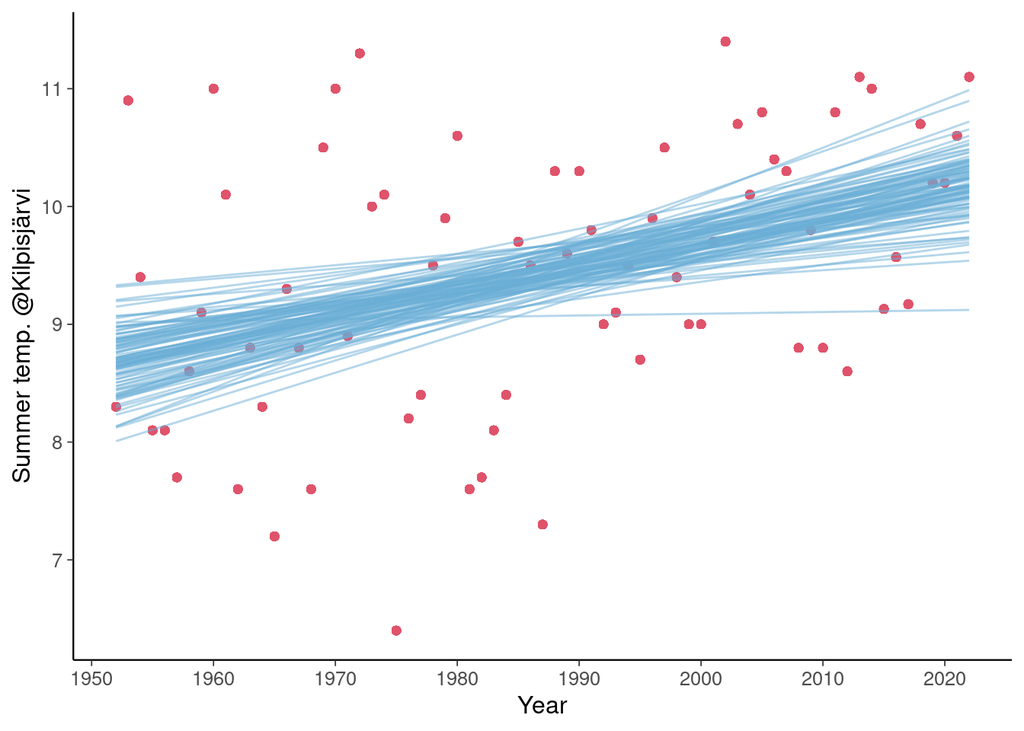

```r
data_lin |>
  add_linpred_draws(fit_lin, ndraws=100) |>
  # plot data
  ggplot(aes(x=year, y=temp)) +
  geom_point(color=2) +
  # plot a line for each posterior draw
  geom_line(aes(y=.linpred, group=.draw), alpha = 1/2, color = brewer.pal(5, "Blues")[[3]])+
  # decoration
  scale_fill_brewer()+
  labs(x= "Year", y = 'Summer temp. @Kilpisjärvi') +
  theme(legend.position="none")+
  scale_x_continuous(breaks=seq(1950,2020,by=10))
```

Plot posterior predictive distribution at each year until 2030 `add_predicted_draws()` takes the years from the data and uses `fit_lin` to make the predictions.

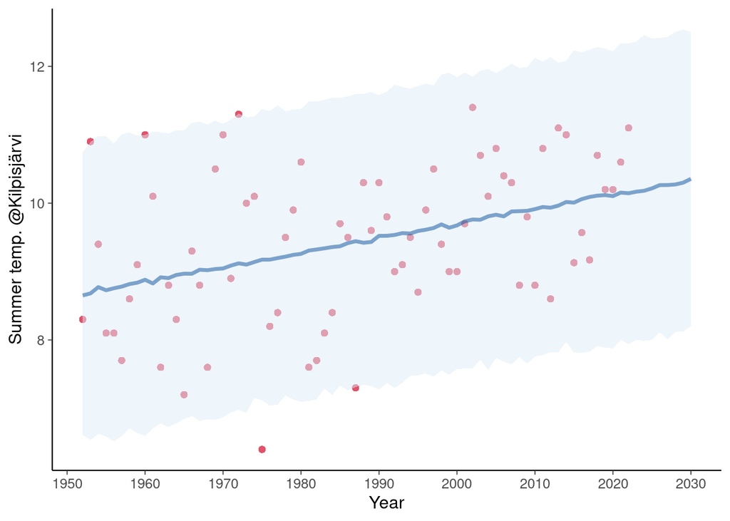

```r
data_lin |>
  add_row(year=2023:2030) |>
  add_predicted_draws(fit_lin) |>
  # plot data
  ggplot(aes(x=year, y=temp)) +
  geom_point(color=2) +
  # plot lineribbon for the linear model
  stat_lineribbon(aes(y = .prediction), .width = c(.95), alpha = 1/2, color=brewer.pal(5, "Blues")[[5]]) +
  # decoration
  scale_fill_brewer()+
  labs(x= "Year", y = 'Summer temp. @Kilpisjärvi') +
  theme(legend.position="none")+
  scale_x_continuous(breaks=seq(1950,2030,by=10))
```

LOO-PIT check is good for checking whether the normal distribution is well describing the variation. LOO-PIT ploty looks good.

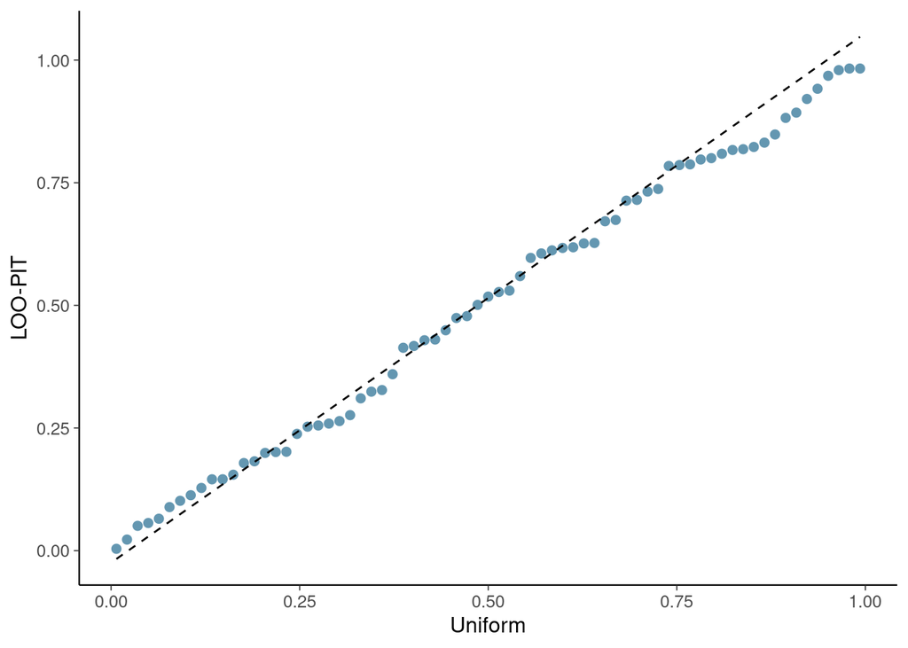

```r
pp_check(fit_lin, type='loo_pit_qq', ndraws=4000)
```

# 6 Linear Student’s $t$ model

The temperatures used in the above analyses are averages over three months, which makes it more likely that they are normally distributed, but there can be extreme events in the feather and we can check whether more robust Student’s $t$ observation model would give different results (although LOO-PIT check did already indicate that the normal would be good).

```r
fit_lin_t <- brm(temp ~ year, data = data_lin, family = student(),
                 prior = prior(student_t(3, 0, 0.03), class='b'),
                 seed = SEED, refresh = 0)
```

Check the summary of the posterior and convergence. The b_year posterior looks similar as before and the posterior for degrees of freedom `nu` has most of the posterior mass for quite large values indicating there is no strong support for thick tailed variation in average summer temperatures.

```r
fit_lin_t
```

```
 Family: student
  Links: mu = identity; sigma = identity; nu = identity
Formula: temp ~ year
   Data: data_lin (Number of observations: 71)
  Draws: 4 chains, each with iter = 2000; warmup = 1000; thin = 1;
         total post-warmup draws = 4000

Population-Level Effects:
          Estimate Est.Error l-95% CI u-95% CI Rhat Bulk_ESS Tail_ESS
Intercept   -34.01     12.27   -58.50    -9.31 1.00     3979     2893
year          0.02      0.01     0.01     0.03 1.00     3979     2923

Family Specific Parameters:
      Estimate Est.Error l-95% CI u-95% CI Rhat Bulk_ESS Tail_ESS
sigma     1.03      0.10     0.86     1.24 1.00     3209     2302
nu       24.54     14.36     6.36    60.80 1.00     2972     2325

Draws were sampled using sample(hmc). For each parameter, Bulk_ESS
and Tail_ESS are effective sample size measures, and Rhat is the potential
scale reduction factor on split chains (at convergence, Rhat = 1).
```

# 7 Pareto-smoothed importance-sampling leave-one-out cross-validation (PSIS-LOO)

We can use leave-one-out cross-validation to compare the expected predictive performance.

LOO comparison shows normal and Student’s $t$ model have similar performance.

```r
loo_compare(loo(fit_lin), loo(fit_lin_t))
```

```
          elpd_diff se_diff
fit_lin    0.0       0.0
fit_lin_t -0.4       0.3
```

# 8 Heteroskedastic linear model

Heteroskedasticity assumes that the variation around the linear mean can also vary. We can allow sigma to depend on year, too. Although the additional component is written as `sigma ~ year`, the log link function is used and the model is for log(sigma). `bf()` allows listing several formulas.

```r
fit_lin_h <- brm(bf(temp ~ year,
                    sigma ~ year),
                 data = data_lin, family = gaussian(),
                 prior = prior(student_t(3, 0, 0.03), class='b'),
                 seed = SEED, refresh = 0)
```

Check the summary of the posterior and convergence. The b_year posterior looks similar as before. The posterior for sigma_year looks like having mosst of the ma for negative values, indicating decrease in temperature variation around the mean.

```r
fit_lin_h
```

```
 Family: gaussian
  Links: mu = identity; sigma = log
Formula: temp ~ year
         sigma ~ year
   Data: data_lin (Number of observations: 71)
  Draws: 4 chains, each with iter = 2000; warmup = 1000; thin = 1;
         total post-warmup draws = 4000

Population-Level Effects:
                Estimate Est.Error l-95% CI u-95% CI Rhat Bulk_ESS Tail_ESS
Intercept         -36.37     12.49   -61.25   -10.49 1.00     3412     2842
sigma_Intercept    19.10      8.69     1.56    35.80 1.00     3818     2899
year                0.02      0.01     0.01     0.04 1.00     3426     2885
sigma_year         -0.01      0.00    -0.02    -0.00 1.00     3810     2855

Draws were sampled using sample(hmc). For each parameter, Bulk_ESS
and Tail_ESS are effective sample size measures, and Rhat is the potential
scale reduction factor on split chains (at convergence, Rhat = 1).
```

Histogram of b_year and b_sigma_year

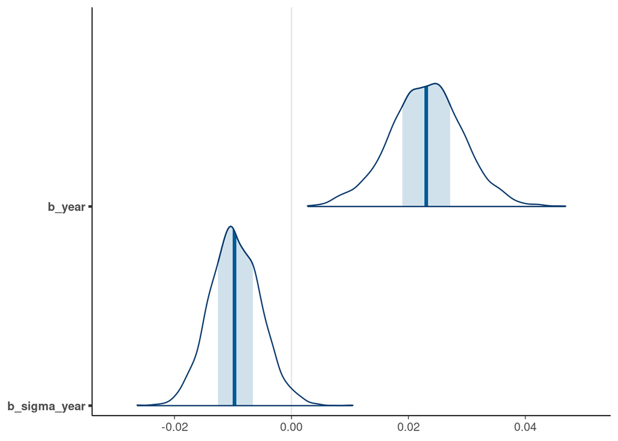

```r
as_draws_df(fit_lin_h) |>
  mcmc_areas(pars=c('b_year', 'b_sigma_year'))
```

As log(x) is almost linear when x is close to zero, we can see that the sigma is decreasing about 1% per year (95% interval from 0% to 2%).

Plot posterior predictive distribution at each year until 2030 `add_predicted_draws()` takes the years from the data and uses `fit_lin_h` to make the predictions.

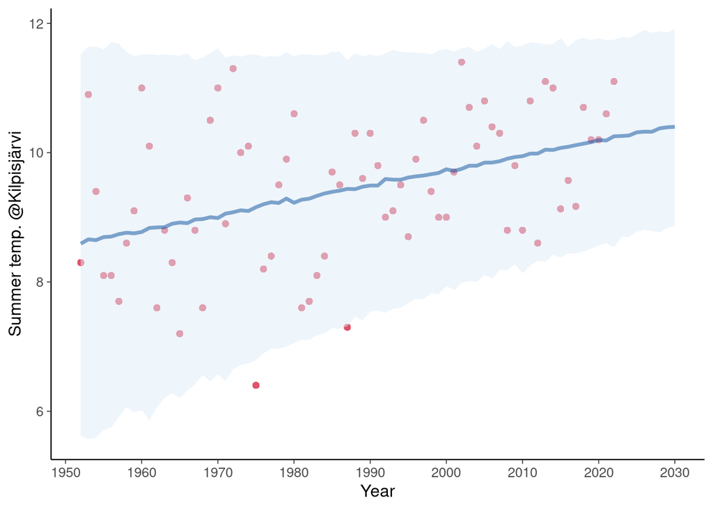

```r
data_lin |>
  add_row(year=2023:2030) |>
  add_predicted_draws(fit_lin_h) |>
  # plot data
  ggplot(aes(x=year, y=temp)) +
  geom_point(color=2) +
  # plot lineribbon for the linear model
  stat_lineribbon(aes(y = .prediction), .width = c(.95), alpha = 1/2, color=brewer.pal(5, "Blues")[[5]]) +
  # decoration
  scale_fill_brewer()+
  labs(x= "Year", y = 'Summer temp. @Kilpisjärvi') +
  theme(legend.position="none")+
  scale_x_continuous(breaks=seq(1950,2030,by=10))
```

Make prior sensitivity analysis by powerscaling both prior and likelihood.

```r
powerscale_sensitivity(fit_lin_h)$sensitivity |>
                                mutate(across(where(is.double),  ~num(.x, digits=2)))
```

```
# A tibble: 4 × 4
  variable              prior likelihood diagnosis
  <chr>             <num:.2!>  <num:.2!> <chr>
1 b_Intercept            0.03       0.11 -
2 b_sigma_Intercept      0.00       0.10 -
3 b_year                 0.03       0.11 -
4 b_sigma_year           0.00       0.11 -
```

We can use leave-one-out cross-validation to compare the expected predictive performance.

LOO comparison shows homoskedastic normal and heteroskedastic normal models have similar performances.

```r
loo_compare(loo(fit_lin), loo(fit_lin_h))
```

```
          elpd_diff se_diff
fit_lin_h  0.0       0.0
fit_lin   -1.6       1.6
```

# 9 Heteroskedastic non-linear model

We can test the linearity assumption by using non-linear spline functions, by uing `s(year)` terms. Sampling is slower as the posterior gets more complex.

```r
fit_spline_h <- brm(bf(temp ~ s(year),
                     sigma ~ s(year)),
                  data = data_lin, family = gaussian(),
                  seed = SEED, refresh = 0)
```

We get warnings about divergences, and try rerunning with higher adapt_delta, which leads to using smaller step sizes. Often `adapt_delta=0.999` leads to very slow sampling, but with this small data, this is not an issue.

```r
fit_spline_h <- update(fit_spline_h, control = list(adapt_delta=0.999))
```

Check the summary of the posterior and convergence. We’re not anymore able to make interpretation of the temperature increase based on this summary. For splines, we see prior scales `sds` for the spline coefficients.

```r
fit_spline_h
```

```
Warning: There were 1 divergent transitions after warmup. Increasing
adapt_delta above 0.999 may help. See
http://mc-stan.org/misc/warnings.html#divergent-transitions-after-warmup
```

```
 Family: gaussian
  Links: mu = identity; sigma = log
Formula: temp ~ s(year)
         sigma ~ s(year)
   Data: data_lin (Number of observations: 71)
  Draws: 4 chains, each with iter = 2000; warmup = 1000; thin = 1;
         total post-warmup draws = 4000

Smooth Terms:
                   Estimate Est.Error l-95% CI u-95% CI Rhat Bulk_ESS Tail_ESS
sds(syear_1)           1.05      0.99     0.04     3.74 1.00     1616     1964
sds(sigma_syear_1)     0.97      0.99     0.02     3.50 1.00     1027     1621

Population-Level Effects:
                Estimate Est.Error l-95% CI u-95% CI Rhat Bulk_ESS Tail_ESS
Intercept           9.42      0.13     9.16     9.68 1.00     4592     2816
sigma_Intercept     0.04      0.09    -0.13     0.21 1.00     4550     2744
syear_1             2.94      2.76    -2.79     9.68 1.00     2133     1835
sigma_syear_1      -1.14      2.65    -7.11     4.16 1.00     1405     1068

Draws were sampled using sample(hmc). For each parameter, Bulk_ESS
and Tail_ESS are effective sample size measures, and Rhat is the potential
scale reduction factor on split chains (at convergence, Rhat = 1).
```

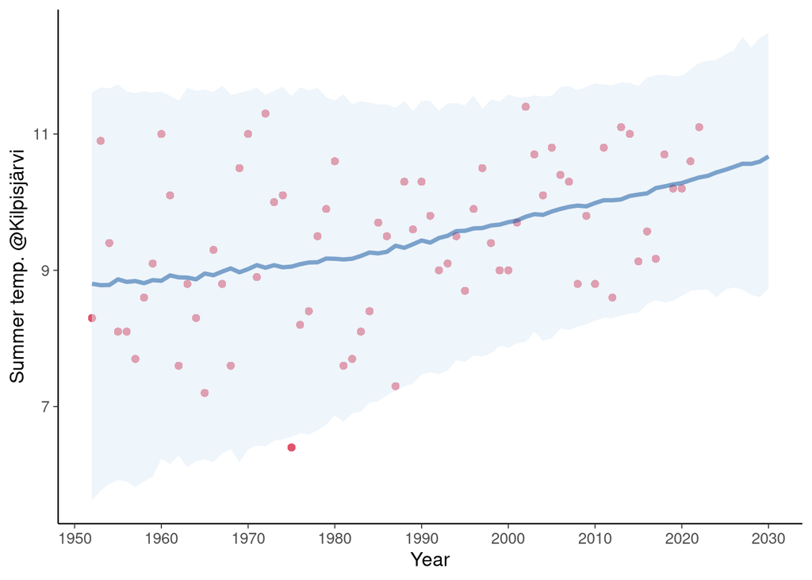

```r
data_lin |>
  add_row(year=2023:2030) |>
  add_predicted_draws(fit_spline_h) |>
  # plot data
  ggplot(aes(x=year, y=temp)) +
  geom_point(color=2) +
  # plot lineribbon for the linear model
  stat_lineribbon(aes(y = .prediction), .width = c(.95), alpha = 1/2, color=brewer.pal(5, "Blues")[[5]]) +
  # decoration
  scale_fill_brewer()+
  labs(x= "Year", y = 'Summer temp. @Kilpisjärvi') +
  theme(legend.position="none")+
  scale_x_continuous(breaks=seq(1950,2030,by=10))
```

And we can use leave-one-out cross-validation to compare the expected predictive performance.

LOO comparison shows homoskedastic normal linear and heteroskedastic normal spline models have similar performances. There are not enough observations to make clear difference between the models.

```r
loo_compare(loo(fit_lin), loo(fit_spline_h))
```

```
             elpd_diff se_diff
fit_spline_h  0.0       0.0
fit_lin      -0.6       1.8
```

For spline and other non-parametric models, we can use predictive estimates and predictions to get interpretable quantities. Let’s examine the difference of estimated average temperature in years 1952 and 2022.

```r
temp_diff <- posterior_epred(fit_spline_h, newdata=filter(data_lin,year==1952|year==2022)) |>
  rvar() |>
  diff() |>
  as_draws_df() |>
  set_variables('temp_diff')

temp_diff <- data_lin |>
  filter(year==1952|year==2022) |>
  add_epred_draws(fit_spline_h) |>
  pivot_wider(id_cols=.draw, names_from = year, values_from = .epred) |>
  mutate(temp_diff = `2022`-`1952`,
         .chain = (.draw - 1) %/% 1000 + 1,
         .iteration = (.draw - 1) %% 1000 + 1) |>
  as_draws_df() |>
  subset_draws(variable='temp_diff')
```

Posterior distribution for average summer temperature increase from 1952 to 2022

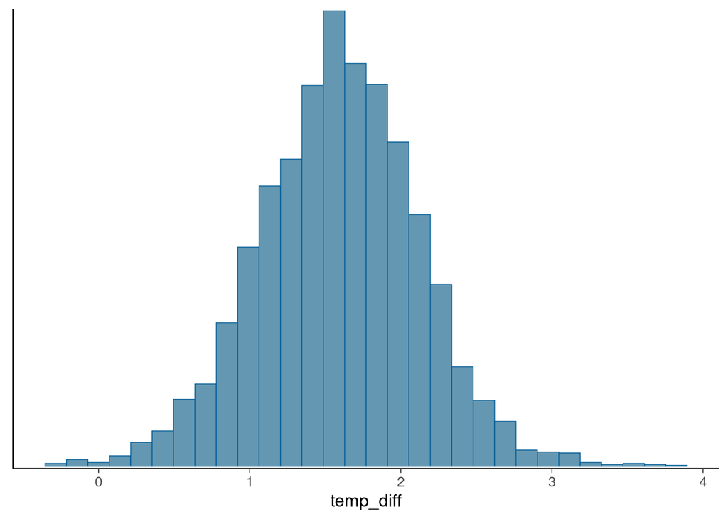

```r
temp_diff |>
  mcmc_hist()
```

95% posterior interval for average summer temperature increase from 1952 to 2022

```r
temp_diff |>
  summarise_draws(~quantile(.x, probs = c(0.025, 0.975)),
                  ~mcse_quantile(.x, probs = c(0.025, 0.975)),
                  .num_args = list(digits = 2, notation = "dec"))
```

```
# A tibble: 1 × 5
  variable  `2.5%` `97.5%` mcse_q2.5 mcse_q97.5
  <chr>      <dbl>   <dbl>     <dbl>      <dbl>
1 temp_diff   0.53    2.64      0.02       0.04
```

Make prior sensitivity analysis by powerscaling both prior and likelihood with focus on average summer temperature increase from 1952 to 2022.

```r
powerscale_sensitivity(fit_spline_h, prediction = \(x, ...) temp_diff, num_args=list(digits=2)
                       )$sensitivity |>
                         filter(variable=='temp_diff') |>
                         mutate(across(where(is.double),  ~num(.x, digits=2)))
```

```
# A tibble: 1 × 4
  variable      prior likelihood diagnosis
  <chr>     <num:.2!>  <num:.2!> <chr>
1 temp_diff      0.01       0.08 -
```

```r
temp_diff |>
  mutate(I_temp_diff_gt_0 = temp_diff>0,
         temp_diff = NULL) |>
  subset_draws(variable='I_temp_diff_gt_0') |>
  summarise_draws(mean, mcse_mean)
```

```
# A tibble: 1 × 3
  variable          mean mcse_mean
  <chr>            <dbl>     <dbl>
1 I_temp_diff_gt_0 0.997  0.000896
```

# 10 Comparison of k groups with hierarchical normal models

Load factory data, which contain 5 quality measurements for each of 6 machines. We’re interested in analysing are the quality differences between the machines.

```r
factory <- read.table(url('https://raw.githubusercontent.com/avehtari/BDA_course_Aalto/master/rpackage/data-raw/factory.txt'))
colnames(factory) <- 1:6
factory
```

```
   1   2   3   4   5   6
1 83 117 101 105  79  57
2 92 109  93 119  97  92
3 92 114  92 116 103 104
4 46 104  86 102  79  77
5 67  87  67 116  92 100
```

We pivot the data to long format

```r
factory <- factory |>
  pivot_longer(cols = everything(),
               names_to = 'machine',
               values_to = 'quality')
factory
```

```
# A tibble: 30 × 2
   machine quality
   <chr>     <int>
 1 1            83
 2 2           117
 3 3           101
 4 4           105
 5 5            79
 6 6            57
 7 1            92
 8 2           109
 9 3            93
10 4           119
# ℹ 20 more rows
```

## 10.1 Pooled model

As comparison make also pooled model

```r
fit_pooled <- brm(quality ~ 1, data = factory, refresh=0)
```

Check the summary of the posterior and convergence.

```r
fit_pooled
```

```
 Family: gaussian
  Links: mu = identity; sigma = identity
Formula: quality ~ 1
   Data: factory (Number of observations: 30)
  Draws: 4 chains, each with iter = 2000; warmup = 1000; thin = 1;
         total post-warmup draws = 4000

Population-Level Effects:
          Estimate Est.Error l-95% CI u-95% CI Rhat Bulk_ESS Tail_ESS
Intercept    92.93      3.35    86.38    99.57 1.00     3295     2295

Family Specific Parameters:
      Estimate Est.Error l-95% CI u-95% CI Rhat Bulk_ESS Tail_ESS
sigma    18.41      2.45    14.27    23.86 1.00     2833     1901

Draws were sampled using sample(hmc). For each parameter, Bulk_ESS
and Tail_ESS are effective sample size measures, and Rhat is the potential
scale reduction factor on split chains (at convergence, Rhat = 1).
```

## 10.2 Separate model

As comparison make also seprate model. To make it completely separate we need to have different sigma for each machine, too.

```r
fit_separate <- brm(bf(quality ~ 0 + machine,
                       sigma ~ 0 + machine),
                    data = factory, refresh=0)
```

Check the summary of the posterior and convergence.

```r
fit_separate
```

```
 Family: gaussian
  Links: mu = identity; sigma = log
Formula: quality ~ 0 + machine
         sigma ~ 0 + machine
   Data: factory (Number of observations: 30)
  Draws: 4 chains, each with iter = 2000; warmup = 1000; thin = 1;
         total post-warmup draws = 4000

Population-Level Effects:
               Estimate Est.Error l-95% CI u-95% CI Rhat Bulk_ESS Tail_ESS
machine1          75.80     13.19    51.02   101.41 1.00     1999     1053
machine2         106.26      7.07    91.88   121.16 1.00     2374     1451
machine3          87.98      7.26    73.76   103.36 1.00     2367     1782
machine4         111.64      4.48   102.43   120.70 1.00     2655     1696
machine5          89.79      6.77    75.32   102.74 1.00     1989     1383
machine6          86.28     12.36    62.77   110.47 1.00     1960     1334
sigma_machine1     3.11      0.40     2.47     4.05 1.00     1753     1236
sigma_machine2     2.61      0.40     1.94     3.49 1.00     2617     1680
sigma_machine3     2.67      0.39     2.03     3.53 1.00     2892     2107
sigma_machine4     2.15      0.39     1.50     3.06 1.00     1958     1474
sigma_machine5     2.51      0.41     1.85     3.46 1.00     2080     1404
sigma_machine6     3.09      0.40     2.45     4.01 1.00     2284     1171

Draws were sampled using sample(hmc). For each parameter, Bulk_ESS
and Tail_ESS are effective sample size measures, and Rhat is the potential
scale reduction factor on split chains (at convergence, Rhat = 1).
```

# 11 Common variance hierarchical model (ANOVA)

```r
fit_hier <- brm(quality ~ 1 + (1 | machine),
                data = factory, refresh = 0)
```

Check the summary of the posterior and convergence.

```r
fit_hier
```

```
 Family: gaussian
  Links: mu = identity; sigma = identity
Formula: quality ~ 1 + (1 | machine)
   Data: factory (Number of observations: 30)
  Draws: 4 chains, each with iter = 2000; warmup = 1000; thin = 1;
         total post-warmup draws = 4000

Group-Level Effects:
~machine (Number of levels: 6)
              Estimate Est.Error l-95% CI u-95% CI Rhat Bulk_ESS Tail_ESS
sd(Intercept)    12.91      5.85     3.82    27.17 1.00      948      925

Population-Level Effects:
          Estimate Est.Error l-95% CI u-95% CI Rhat Bulk_ESS Tail_ESS
Intercept    92.79      5.99    80.86   104.87 1.00     1197     1027

Family Specific Parameters:
      Estimate Est.Error l-95% CI u-95% CI Rhat Bulk_ESS Tail_ESS
sigma    15.05      2.26    11.39    20.19 1.00     1986     2162

Draws were sampled using sample(hmc). For each parameter, Bulk_ESS
and Tail_ESS are effective sample size measures, and Rhat is the potential
scale reduction factor on split chains (at convergence, Rhat = 1).
```

LOO comparison shows the hierarchical model is the best. The differences are small as the number of observations is small and there is a considerable prediction (aleatoric) uncertainty.

```r
loo_compare(loo(fit_pooled), loo(fit_separate), loo(fit_hier))
```

```
             elpd_diff se_diff
fit_hier      0.0       0.0
fit_separate -3.5       2.7
fit_pooled   -4.3       2.0
```

Different model posterior distributions for the mean quality. Pooled model ignores the varition between machines. Separate model doesn’t take benefit from the similariy of the machines and has higher uncertainty.

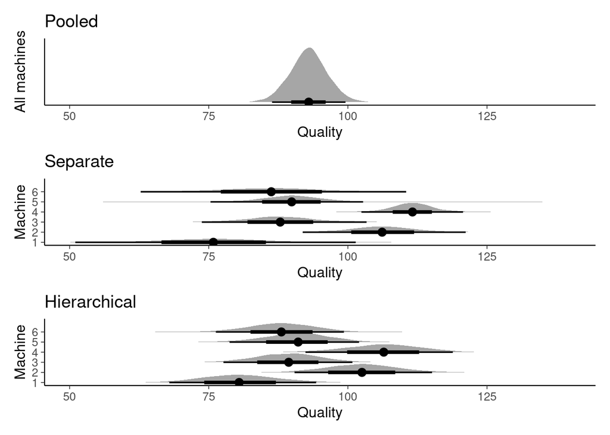

```r
ph <- fit_hier |>
  spread_rvars(b_Intercept, r_machine[machine,]) |>
  mutate(machine_mean = b_Intercept + r_machine) |>
  ggplot(aes(xdist=machine_mean, y=machine)) +
  stat_halfeye() +
  scale_y_continuous(breaks=1:6) +
  labs(x='Quality', y='Machine', title='Hierarchical')

ps <- fit_separate |>
  as_draws_df() |>
  subset_draws(variable='b_machine', regex=TRUE) |>
  set_variables(paste0('b_machine[', 1:6, ']')) |>
  as_draws_rvars() |>
  spread_rvars(b_machine[machine]) |>
  mutate(machine_mean = b_machine) |>
  ggplot(aes(xdist=machine_mean, y=machine)) +
  stat_halfeye() +
  scale_y_continuous(breaks=1:6) +
  labs(x='Quality', y='Machine', title='Separate')

pp <- fit_pooled |>
  spread_rvars(b_Intercept) |>
  mutate(machine_mean = b_Intercept) |>
  ggplot(aes(xdist=machine_mean, y=0)) +
  stat_halfeye() +
  scale_y_continuous(breaks=NULL) +
  labs(x='Quality', y='All machines', title='Pooled')

(pp / ps / ph) * xlim(c(50,140))
```

Make prior sensitivity analysis by powerscaling both prior and likelihood with focus on mean quality of each machine. We see no prior sensitivity.

```r
machine_mean <- fit_hier |>
  as_draws_df() |>
  mutate(across(matches('r_machine'), ~ .x - b_Intercept)) |>
  subset_draws(variable='r_machine', regex=TRUE) |>
  set_variables(paste0('machine_mean[', 1:6, ']'))
powerscale_sensitivity(fit_hier, prediction = \(x, ...) machine_mean, num_args=list(digits=2)
                       )$sensitivity |>
                         filter(str_detect(variable,'machine_mean')) |>
                         mutate(across(where(is.double),  ~num(.x, digits=2)))
```

```
# A tibble: 6 × 4
  variable            prior likelihood diagnosis
  <chr>           <num:.2!>  <num:.2!> <chr>
1 machine_mean[1]      0.03       0.08 -
2 machine_mean[2]      0.03       0.06 -
3 machine_mean[3]      0.03       0.03 -
4 machine_mean[4]      0.03       0.09 -
5 machine_mean[5]      0.03       0.02 -
6 machine_mean[6]      0.03       0.04 -
```

# 12 Hierarchical binomial model

[Sorafenib Toxicity Dataset in `metadat` R package](https://wviechtb.github.io/metadat/reference/dat.ursino2021.html) includes results from 13 studies investigating the occurrence of dose limiting toxicities (DLTs) at different doses of Sorafenib.

Load data

```r
load(url('https://github.com/wviechtb/metadat/raw/master/data/dat.ursino2021.rda'))
head(dat.ursino2021)
```

```
  study year dose events total
1 Awada 2005  100      0     4
2 Awada 2005  200      0     3
3 Awada 2005  300      1     5
4 Awada 2005  400      1    10
5 Awada 2005  600      7    12
6 Awada 2005  800      1     3
```

Pooled model assumes all studies have the same dose effect (reminder: `~ dose` is equivalent to `~ 1 + dose`)

```r
fit_pooled <- brm(events | trials(total) ~ dose,
                  prior = c(prior(student_t(7, 0, 1.5), class='Intercept'),
                            prior(normal(0, 1), class='b')),
                  family=binomial(), data=dat.ursino2021)
```

Check the summary of the posterior and convergence

```r
fit_pooled
```

```
 Family: binomial
  Links: mu = logit
Formula: events | trials(total) ~ dose
   Data: dat.ursino2021 (Number of observations: 49)
  Draws: 4 chains, each with iter = 2000; warmup = 1000; thin = 1;
         total post-warmup draws = 4000

Population-Level Effects:
          Estimate Est.Error l-95% CI u-95% CI Rhat Bulk_ESS Tail_ESS
Intercept    -3.16      0.37    -3.90    -2.47 1.00     1450     2111
dose          0.00      0.00     0.00     0.01 1.00     2718     2666

Draws were sampled using sample(hmc). For each parameter, Bulk_ESS
and Tail_ESS are effective sample size measures, and Rhat is the potential
scale reduction factor on split chains (at convergence, Rhat = 1).
```

Dose coefficient seems to be very small. Looking at the posterior, we see that it is positive with high probability.

```r
fit_pooled |>
  as_draws() |>
  subset_draws(variable='b_dose') |>
  summarise_draws(~quantile(.x, probs = c(0.025, 0.975)), ~mcse_quantile(.x, probs = c(0.025, 0.975)))
```

```
# A tibble: 1 × 5
  variable  `2.5%` `97.5%` mcse_q2.5 mcse_q97.5
  <chr>      <dbl>   <dbl>     <dbl>      <dbl>
1 b_dose   0.00231 0.00514 0.0000446  0.0000332
```

The dose was reported in mg, and most values are in hundreds. It is often sensible to switch to a scale in which the range of values is closer to unit range. In this case it is natural to use g instead of mg.

```r
dat.ursino2021 <- dat.ursino2021 |>
  mutate(doseg = dose/100)
```

Fit the pooled model again uing `doseg`

```r
fit_pooled <- brm(events | trials(total) ~ doseg,
                  prior = c(prior(student_t(7, 0, 1.5), class='Intercept'),
                            prior(normal(0, 1), class='b')),
                  family=binomial(), data=dat.ursino2021)
```

Check the summary of the posterior and convergence.

```r
fit_pooled
```

```
 Family: binomial
  Links: mu = logit
Formula: events | trials(total) ~ doseg
   Data: dat.ursino2021 (Number of observations: 49)
  Draws: 4 chains, each with iter = 2000; warmup = 1000; thin = 1;
         total post-warmup draws = 4000

Population-Level Effects:
          Estimate Est.Error l-95% CI u-95% CI Rhat Bulk_ESS Tail_ESS
Intercept    -3.15      0.36    -3.86    -2.44 1.00     1965     2291
doseg         0.37      0.07     0.22     0.51 1.00     2383     2460

Draws were sampled using sample(hmc). For each parameter, Bulk_ESS
and Tail_ESS are effective sample size measures, and Rhat is the potential
scale reduction factor on split chains (at convergence, Rhat = 1).
```

Now it is easier to interpret the presented values. Separate model assumes all studies have different dose effect. It would be a bit complicated to set a different prior on study specific intercepts and other coefficients, so we use the ame prior for all.

```r
fit_separate <- brm(events | trials(total) ~ 0 + study + doseg:study,
                    prior=prior(student_t(7, 0, 1.5), class='b'),
                    family=binomial(), data=dat.ursino2021)
```

Check the summary of the posterior and convergence.

```r
fit_separate
```

```
 Family: binomial
  Links: mu = logit
Formula: events | trials(total) ~ 0 + study + doseg:study
   Data: dat.ursino2021 (Number of observations: 49)
  Draws: 4 chains, each with iter = 2000; warmup = 1000; thin = 1;
         total post-warmup draws = 4000

Population-Level Effects:
                       Estimate Est.Error l-95% CI u-95% CI Rhat Bulk_ESS
studyAwada                -2.67      1.06    -5.00    -0.82 1.00     6374
studyBorthakurMA          -2.45      1.78    -6.50     0.42 1.00     5306
studyBorthakurMB          -1.66      1.43    -4.84     0.84 1.00     6868
studyChen                 -0.80      1.51    -4.14     1.92 1.00     5851
studyClark                -3.05      1.45    -6.23    -0.69 1.00     5479
studyCrumpMA              -1.56      1.27    -4.37     0.72 1.00     7067
studyCrumpMB              -1.85      1.10    -4.24     0.09 1.00     6820
studyFuruse               -1.64      1.58    -4.97     0.98 1.00     5877
studyMiller               -1.11      0.80    -2.74     0.43 1.00     7209
studyMinami               -1.97      1.16    -4.53     0.08 1.00     5790
studyMoore                -2.34      1.24    -5.14    -0.21 1.00     6729
studyNabors               -2.92      1.44    -6.21    -0.47 1.00     5397
studyStrumberg            -1.97      0.85    -3.80    -0.43 1.00     6907
studyAwada:doseg           0.38      0.20     0.00     0.82 1.00     6664
studyBorthakurMA:doseg     0.01      0.40    -0.72     0.83 1.00     5509
studyBorthakurMB:doseg     0.06      0.32    -0.55     0.72 1.00     7201
studyChen:doseg           -0.64      0.51    -1.65     0.39 1.00     4968
studyClark:doseg           0.44      0.25    -0.00     0.97 1.00     5722
studyCrumpMA:doseg        -0.29      0.50    -1.32     0.71 1.00     6885
studyCrumpMB:doseg         0.09      0.27    -0.45     0.64 1.00     6482
studyFuruse:doseg         -0.53      0.58    -1.66     0.59 1.00     5681
studyMiller:doseg          0.02      0.28    -0.54     0.57 1.00     7172
studyMinami:doseg         -0.17      0.35    -0.90     0.49 1.00     5541
studyMoore:doseg           0.21      0.28    -0.33     0.80 1.00     6750
studyNabors:doseg          0.31      0.20    -0.06     0.75 1.00     5900
studyStrumberg:doseg       0.09      0.16    -0.23     0.41 1.00     6629
                       Tail_ESS
studyAwada                 1972
studyBorthakurMA           2352
studyBorthakurMB           2248
studyChen                  2490
```

[output cut: 11 more lines]

```
studyBorthakurMB:doseg     2416
studyChen:doseg            2377
studyClark:doseg           2220
studyCrumpMA:doseg         2479
studyCrumpMB:doseg         2417
studyFuruse:doseg          2244
studyMiller:doseg          2841
studyMinami:doseg          2883
studyMoore:doseg           2338
studyNabors:doseg          2492
studyStrumberg:doseg       2436

Draws were sampled using sample(hmc). For each parameter, Bulk_ESS
and Tail_ESS are effective sample size measures, and Rhat is the potential
scale reduction factor on split chains (at convergence, Rhat = 1).
```

Hierarchical model assumes common mean effect and variation around with normal population prior (reminder: `~ doseg + (doseg | study)` is equivalent to `~ 1 + doseg + (1 + doseg | study)`)

```r
fit_hier <- brm(events | trials(total) ~ doseg + (doseg | study),
                    prior=c(prior(student_t(7, 0, 1.5), class='Intercept'),
                            prior(normal(0, 1), class='b')),
                family=binomial(), data=dat.ursino2021)
```

We seem some divergences and repeat with higher adapt_delta

```r
fit_hier <- update(fit_hier, control=list(adapt_delta=0.99))
```

LOO-CV comparison

```r
loo_compare(loo(fit_pooled), loo(fit_separate), loo(fit_hier))
```

```
Warning: Found 14 observations with a pareto_k > 0.7 in model 'fit_separate'.
It is recommended to set 'moment_match = TRUE' in order to perform moment
matching for problematic observations.
```

```
Warning: Found 1 observations with a pareto_k > 0.7 in model 'fit_hier'. It is
recommended to set 'moment_match = TRUE' in order to perform moment matching
for problematic observations.
```

```
             elpd_diff se_diff
fit_hier       0.0       0.0
fit_pooled    -1.2       2.8
fit_separate -23.1       5.3
```

We get warnings about Pareto k’s > 0.7 in PSIS-LOO for separate model, but as in that case the LOO-CV estimate is usually overoptimistic and the separate model is the worst, there is no need to use more accurate computation.

Hierarchical model has better elpd than the pooled, but difference is negligible. However, when we look at the study specific parameters, we see that the Miller study has higher intercept (more events).

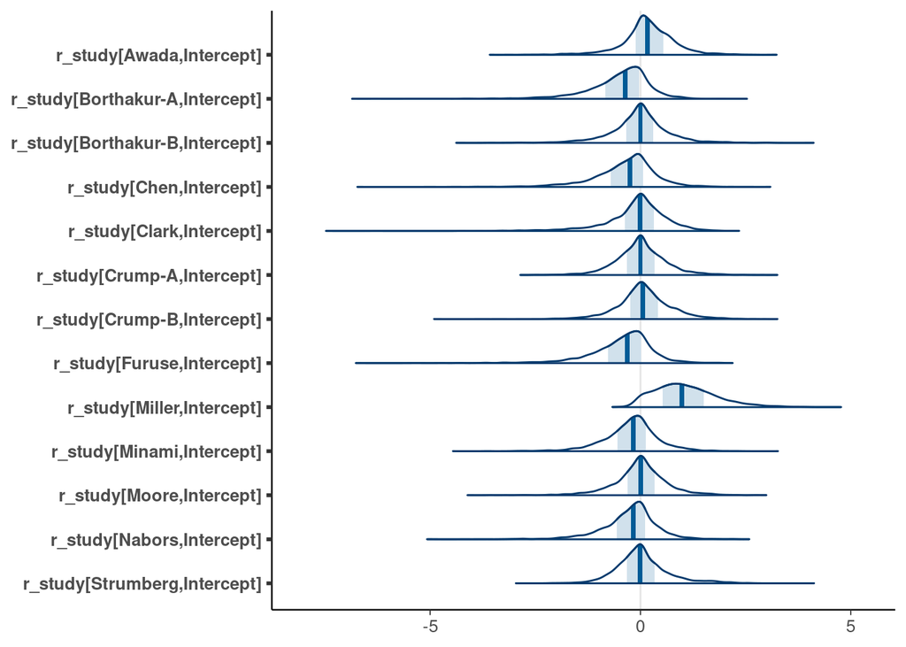

```r
mcmc_areas(as_draws_df(fit_hier), regex_pars='r_study\\[.*Intercept')
```

There are no differences in slopes.

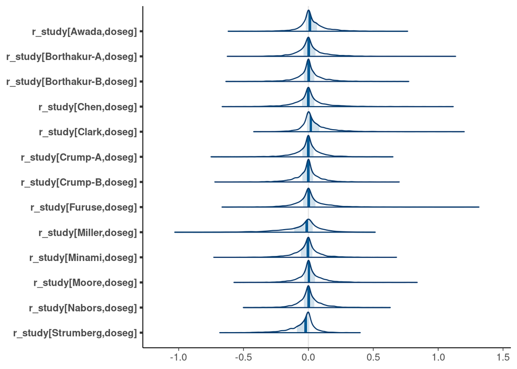

```r
mcmc_areas(as_draws_df(fit_hier), regex_pars='r_study\\[.*doseg')
```

The population level coefficient for the dose is clearly larger than 0

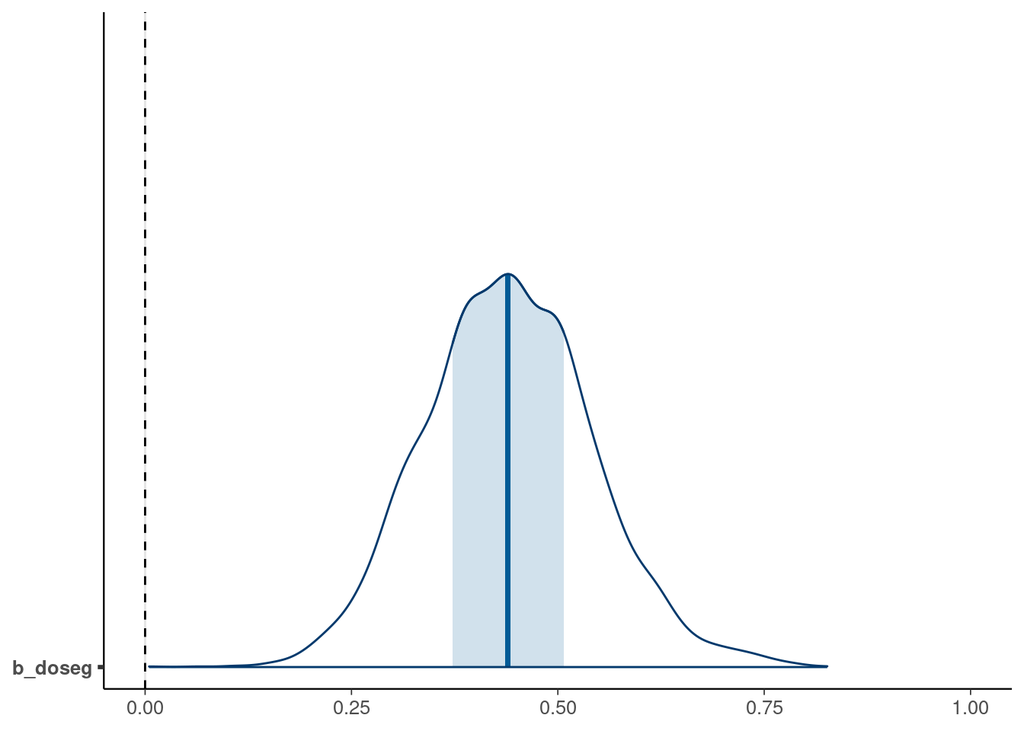

```r
mcmc_areas(as_draws_df(fit_hier), regex_pars='b_doseg') +
  geom_vline(xintercept=0, linetype='dashed') +
  xlim(c(0,1))
```

Make prior sensitivity analysis by powerscaling both prior and likelihood.

```r
powerscale_sensitivity(fit_hier, variable='b_doseg'
                       )$sensitivity |>
                         mutate(across(where(is.double),  ~num(.x, digits=2)))
```

```
# A tibble: 1 × 4
  variable     prior likelihood diagnosis
  <chr>    <num:.2!>  <num:.2!> <chr>
1 b_doseg       0.02       0.12 -
```

The posterior for the probability of event given certain dose and a new study.

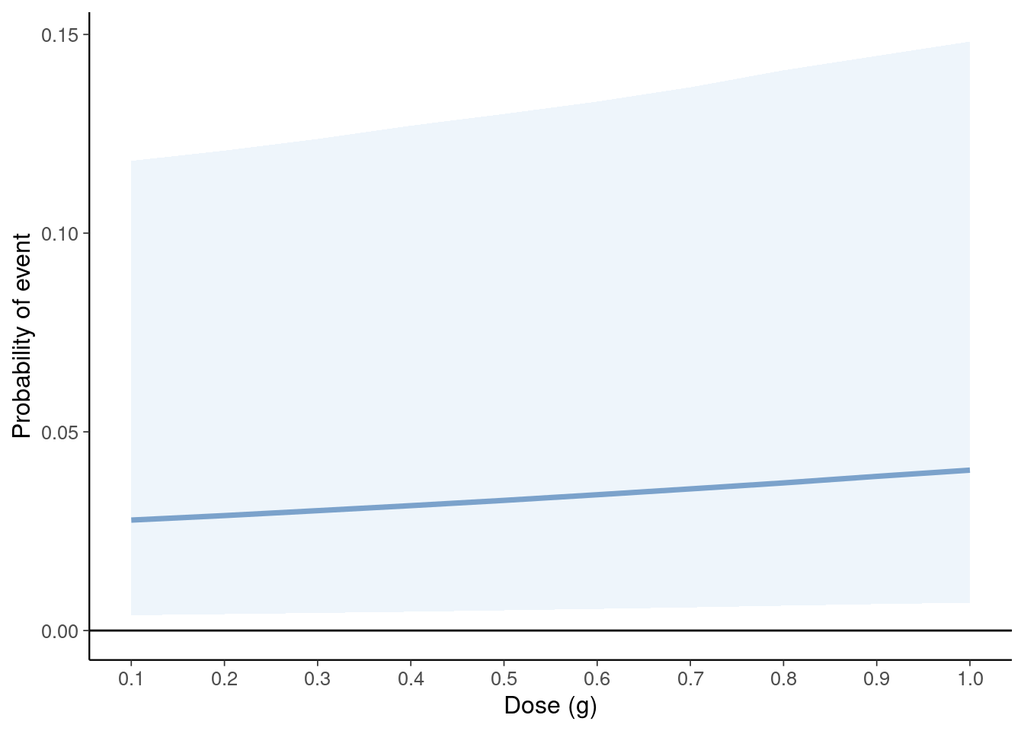

```r
data.frame(study='new',
           doseg=seq(0.1,1,by=0.1),
           total=1) |>
  add_linpred_draws(fit_hier, transform=TRUE, allow_new_levels=TRUE) |>
  ggplot(aes(x=doseg, y=.linpred)) +
  stat_lineribbon(.width = c(.95), alpha = 1/2, color=brewer.pal(5, "Blues")[[5]]) +
  scale_fill_brewer()+
  labs(x= "Dose (g)", y = 'Probability of event') +
  theme(legend.position="none") +
  geom_hline(yintercept=0) +
  scale_x_continuous(breaks=seq(0.1,1,by=0.1))
```

If plot individual posterior draws, we see that there is a lot of uncertainty about the overall probability (explained by the variation in Intercept in different studies), but less uncertainty about the slope.

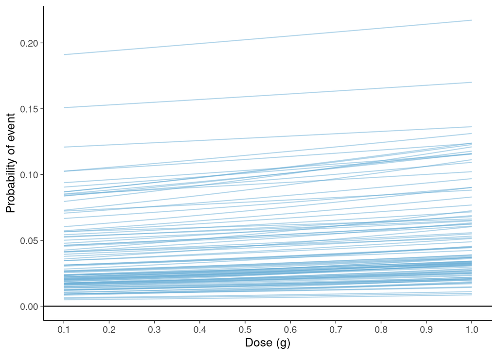

```r
data.frame(study='new',
           doseg=seq(0.1,1,by=0.1),
           total=1) |>
  add_linpred_draws(fit_hier, transform=TRUE, allow_new_levels=TRUE, ndraws=100) |>
  ggplot(aes(x=doseg, y=.linpred)) +
  geom_line(aes(group=.draw), alpha = 1/2, color = brewer.pal(5, "Blues")[[3]])+
  scale_fill_brewer()+
  labs(x= "Dose (g)", y = 'Probability of event') +
  theme(legend.position="none") +
  geom_hline(yintercept=0) +
  scale_x_continuous(breaks=seq(0.1,1,by=0.1))
```

Posterior predictive checking showing the observed and predicted number of events.

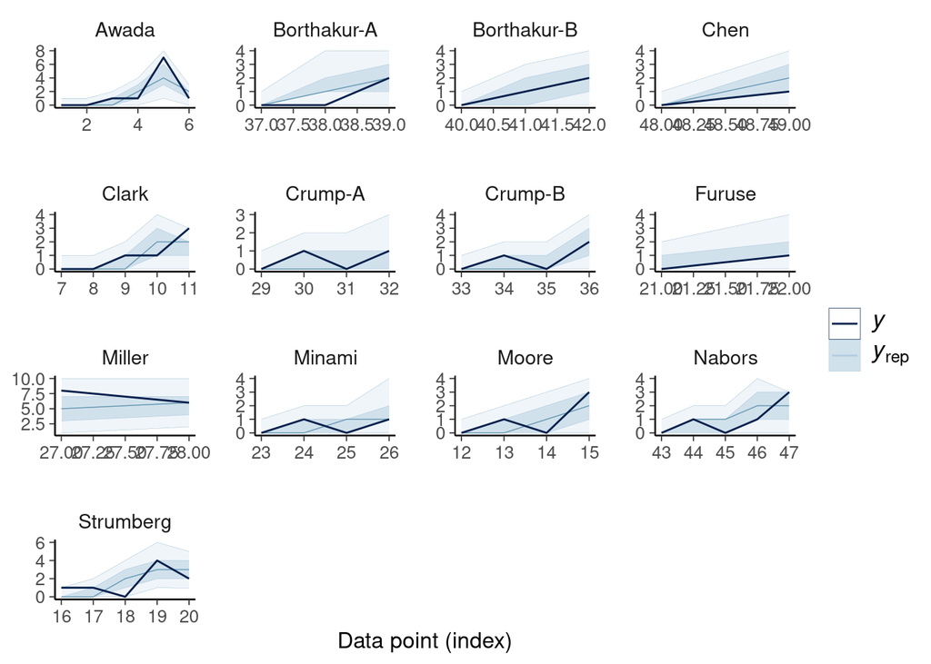

```r
pp_check(fit_hier, type = "ribbon_grouped", group="study")
```

# 13 Hierarchical binomial model

[Studies on Pharmacologic Treatments for Chronic Obstructive Pulmonary Disease](https://wviechtb.github.io/metadat/reference/dat.baker2009.html) includes results from 39 trials examining pharmacologic treatments for chronic obstructive pulmonary disease (COPD).

Load data

```r
load(url('https://github.com/wviechtb/metadat/raw/master/data/dat.baker2009.rda'))
head(dat.baker2009)
```

```
                 study year id   treatment exac total
1 Llewellyn-Jones 1996 1996  1 Fluticasone    0     8
2 Llewellyn-Jones 1996 1996  1     Placebo    3     8
3            Boyd 1997 1997  2  Salmeterol   47   229
4            Boyd 1997 1997  2     Placebo   59   227
5        Paggiaro 1998 1998  3 Fluticasone   45   142
6        Paggiaro 1998 1998  3     Placebo   51   139
```

```r
# force character strings to factors for easier ploting
dat.baker2009 <- dat.baker2009 |>
  mutate(study = factor(study),
         treatment = factor(treatment),
         id = factor(id))
```

The first model is pooling the information over studies, but estimating separate theta for each treatment (including placebo).

```r
fit_pooled <- brm(exac | trials(total) ~ 0 + treatment,
                  prior = prior(student_t(7, 0, 1.5), class='b'),
                  family=binomial(), data=dat.baker2009)
```

Check the summary of the posterior and convergence

```r
fit_pooled
```

```
 Family: binomial
  Links: mu = logit
Formula: exac | trials(total) ~ 0 + treatment
   Data: dat.baker2009 (Number of observations: 94)
  Draws: 4 chains, each with iter = 2000; warmup = 1000; thin = 1;
         total post-warmup draws = 4000

Population-Level Effects:
                                Estimate Est.Error l-95% CI u-95% CI Rhat
treatmentBudesonide                -0.30      0.10    -0.49    -0.12 1.00
treatmentBudesonidePFormoterol     -0.49      0.10    -0.69    -0.30 1.00
treatmentFluticasone                0.35      0.04     0.28     0.43 1.00
treatmentFluticasonePSalmeterol     0.12      0.03     0.05     0.19 1.00
treatmentFormoterol                -0.71      0.06    -0.83    -0.59 1.00
treatmentPlacebo                   -0.28      0.02    -0.32    -0.24 1.00
treatmentSalmeterol                -0.38      0.03    -0.44    -0.33 1.00
treatmentTiotropium                -0.90      0.03    -0.96    -0.85 1.00
                                Bulk_ESS Tail_ESS
treatmentBudesonide                 7624     2716
treatmentBudesonidePFormoterol      6990     3228
treatmentFluticasone                6607     3194
treatmentFluticasonePSalmeterol     6945     3144
treatmentFormoterol                 6658     2810
treatmentPlacebo                    6767     3362
treatmentSalmeterol                 6224     2489
treatmentTiotropium                 7099     3080

Draws were sampled using sample(hmc). For each parameter, Bulk_ESS
and Tail_ESS are effective sample size measures, and Rhat is the potential
scale reduction factor on split chains (at convergence, Rhat = 1).
```

Treatment effect posteriors

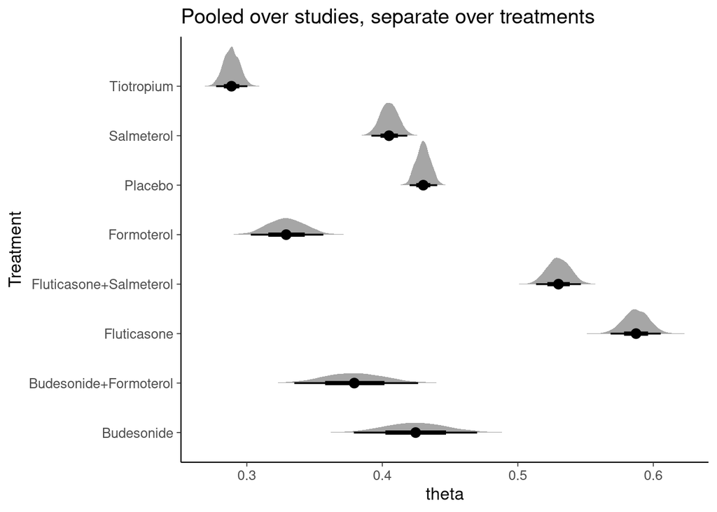

```r
fit_pooled |>
  as_draws_df() |>
  subset_draws(variable='b_', regex=TRUE) |>
  set_variables(paste0('b_treatment[', levels(factor(dat.baker2009$treatment)), ']')) |>
  as_draws_rvars() |>
  spread_rvars(b_treatment[treatment]) |>
  mutate(theta_treatment = rfun(plogis)(b_treatment)) |>
  ggplot(aes(xdist=theta_treatment, y=treatment)) +
  stat_halfeye() +
  labs(x='theta', y='Treatment', title='Pooled over studies, separate over treatments')
```

Treatment effect odds-ratio posteriors

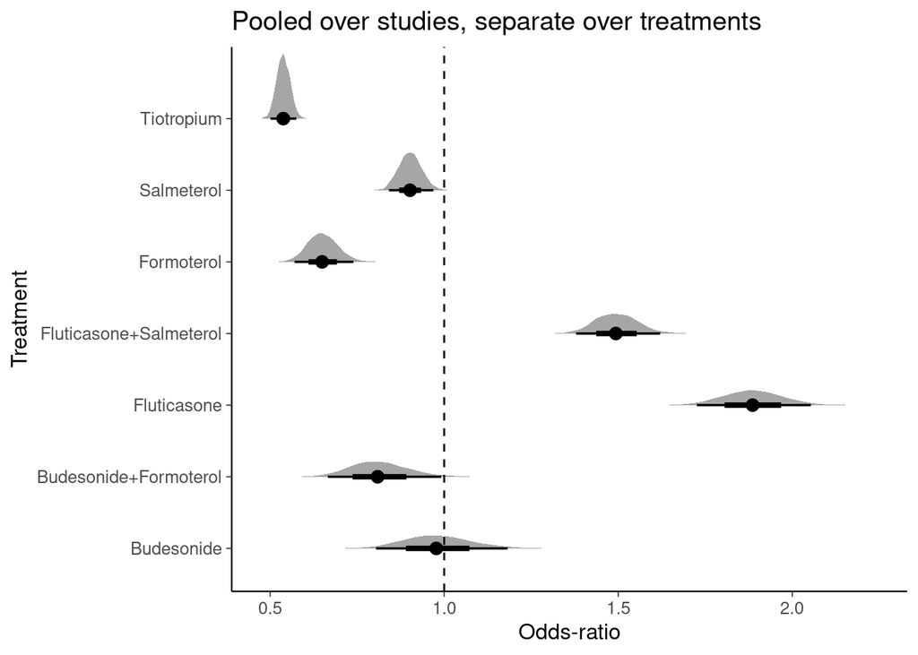

```r
theta <- fit_pooled |>
  as_draws_df() |>
  subset_draws(variable='b_', regex=TRUE) |>
  set_variables(paste0('b_treatment[', levels(factor(dat.baker2009$treatment)), ']')) |>
  as_draws_rvars() |>
  spread_rvars(b_treatment[treatment]) |>
  mutate(theta_treatment = rfun(plogis)(b_treatment))
theta_placebo <- filter(theta,treatment=='Placebo')$theta_treatment[[1]]
theta |>
  mutate(treatment_oddsratio = (theta_treatment/(1-theta_treatment))/(theta_placebo/(1-theta_placebo))) |>
  filter(treatment != "Placebo") |>
  ggplot(aes(xdist=treatment_oddsratio, y=treatment)) +
  stat_halfeye() +
  labs(x='Odds-ratio', y='Treatment', title='Pooled over studies, separate over treatments') +
  geom_vline(xintercept=1, linetype='dashed')
```

We see a big variation between treatments and two treatments seem to be harmful, which is suspicious. Looking at the data we see that not all studies included all treatments, and thus if some of the studies had more events, then the above estimates can be wrong.

Posterior predictive checking with kernel density estimates for the data and 10 posterior predictive replicates shows clear discrepancy.

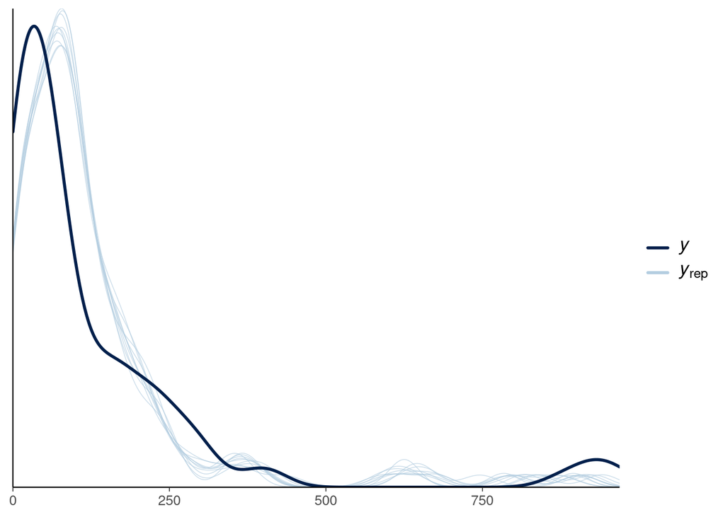

```r
pp_check(fit_pooled, type='dens_overlay')
```

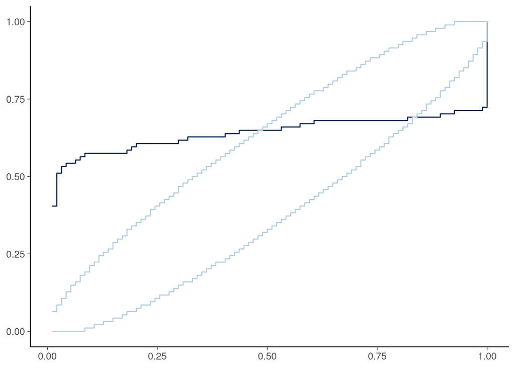

```r
pp_check(fit_pooled, type='pit_ecdf', ndraws=4000)
```

Posterior predictive checking with LOO-PIT values show clear discrepancy.

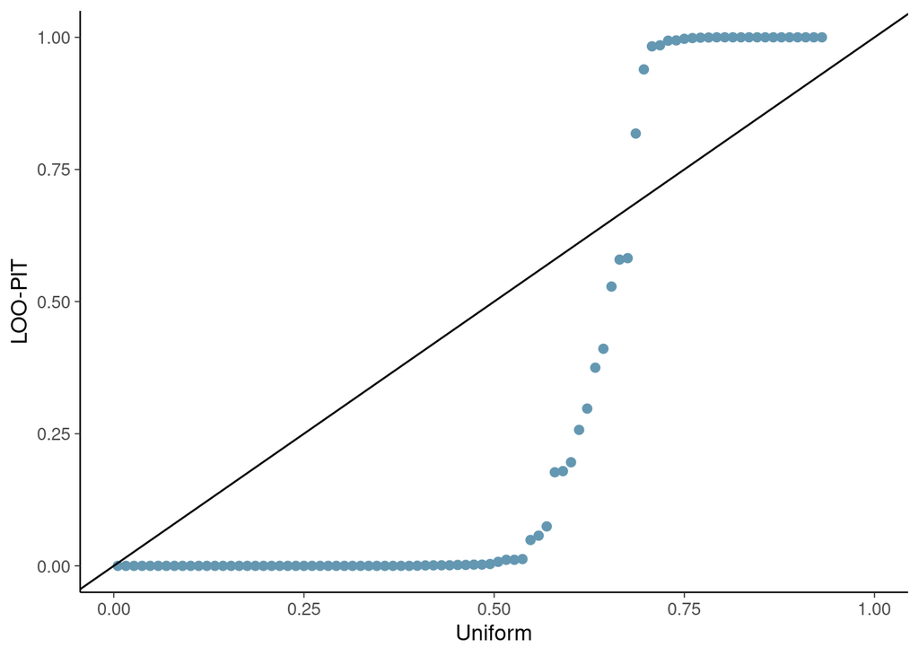

```r
pp_check(fit_pooled, type='loo_pit_qq', ndraws=4000) +
  geom_abline() +
  ylim(c(0,1))
```

The second model uses a hiearchical model both for treatment effects and study effects.

```r
fit_hier <- brm(exac | trials(total) ~ (1 | treatment) + (1 | study),
                family=binomial(), data=dat.baker2009)
```

Check the summary of the posterior and convergence

```r
fit_hier
```

```
 Family: binomial
  Links: mu = logit
Formula: exac | trials(total) ~ (1 | treatment) + (1 | study)
   Data: dat.baker2009 (Number of observations: 94)
  Draws: 4 chains, each with iter = 2000; warmup = 1000; thin = 1;
         total post-warmup draws = 4000

Group-Level Effects:
~study (Number of levels: 39)
              Estimate Est.Error l-95% CI u-95% CI Rhat Bulk_ESS Tail_ESS
sd(Intercept)     1.20      0.17     0.92     1.56 1.01      553     1001

~treatment (Number of levels: 8)
              Estimate Est.Error l-95% CI u-95% CI Rhat Bulk_ESS Tail_ESS
sd(Intercept)     0.17      0.07     0.08     0.34 1.00     1288     2138

Population-Level Effects:
          Estimate Est.Error l-95% CI u-95% CI Rhat Bulk_ESS Tail_ESS
Intercept    -0.93      0.22    -1.38    -0.48 1.02      363      464

Draws were sampled using sample(hmc). For each parameter, Bulk_ESS
and Tail_ESS are effective sample size measures, and Rhat is the potential
scale reduction factor on split chains (at convergence, Rhat = 1).
```

LOO-CV comparison

```r
loo_compare(loo(fit_pooled), loo(fit_hier))
```

```
Warning: Found 24 observations with a pareto_k > 0.7 in model 'fit_pooled'. It
is recommended to set 'moment_match = TRUE' in order to perform moment matching
for problematic observations.
```

```
Warning: Found 18 observations with a pareto_k > 0.7 in model 'fit_hier'. It is
recommended to set 'moment_match = TRUE' in order to perform moment matching
for problematic observations.
```

```
           elpd_diff se_diff
fit_hier       0.0       0.0
fit_pooled -1948.1     299.8
```

We get warnings about Pareto k’s > 0.7 in PSIS-LOO, but as the difference between the models is huge, we can be confident that the order would the same if we fixed the computation, and the hierarchical model is much better and there is high variation between studies. Clearly there are many highly influential observations.